# Ordered Logistic Regression

```r
# save original levels to create df
ms_dx_levels <- levels(pws_multivar_dur_dx_race$model$ms_dx_condensed_2)
ms_dx_levels
```

```
## [1] "RRMS or Not Specified" "Progressive MS"
```

```r
race_levels <- levels(pws_multivar_dur_dx_race$model$race_ethnicity_clean_2)
race_levels
```

```
## [1] "White Not Hispanic"                 "Asian or Black or African American"
## [3] "Hispanic or Latino"                 "Other/Unknown/Declined"
```

```r
# Define continuous variable ranges
disease_duration_values <- seq(from = 0, to = 38, length.out = 100)

# Generate all combinations of categorical variables
cat_combinations <- expand.grid(
  ms_dx_condensed_2 = ms_dx_levels,
  race_ethnicity_clean_2 = race_levels,
  stringsAsFactors = TRUE  # Ensures they are factors
)

head(cat_combinations)
```

```
##       ms_dx_condensed_2             race_ethnicity_clean_2
## 1 RRMS or Not Specified                 White Not Hispanic
## 2        Progressive MS                 White Not Hispanic
## 3 RRMS or Not Specified Asian or Black or African American
## 4        Progressive MS Asian or Black or African American
## 5 RRMS or Not Specified                 Hispanic or Latino
## 6        Progressive MS                 Hispanic or Latino
```

```r
# Expand dataset to include all continuous variable values for each categorical combination
newdat <- expand.grid(
  demoEHR_DiseaseDuration = disease_duration_values,
  stringsAsFactors = FALSE  # Keep continuous variables numeric
)

# Use `merge()` to properly combine categorical and continuous variables
newdat <- merge(cat_combinations, newdat, by = NULL)

# predict for each row of new dat using model
newdat <- cbind(newdat, predict(pws_multivar_dur_dx_race, newdat, type = "probs"))
head(newdat)
```

```
##       ms_dx_condensed_2             race_ethnicity_clean_2
## 1 RRMS or Not Specified                 White Not Hispanic
## 2        Progressive MS                 White Not Hispanic
## 3 RRMS or Not Specified Asian or Black or African American
## 4        Progressive MS Asian or Black or African American
## 5 RRMS or Not Specified                 Hispanic or Latino
## 6        Progressive MS                 Hispanic or Latino
##   demoEHR_DiseaseDuration      mild  moderate     severe
## 1                       0 0.6898825 0.2621172 0.04800029
## 2                       0 0.2023526 0.4910622 0.30658520
## 3                       0 0.1973907 0.4893885 0.31322084
## 4                       0 0.0272809 0.1727469 0.79997222
## 5                       0 0.7573114 0.2079914 0.03469720
## 6                       0 0.2624584 0.4978840 0.23965756
```

```r
head(newdat)
```

```
##       ms_dx_condensed_2             race_ethnicity_clean_2
## 1 RRMS or Not Specified                 White Not Hispanic
## 2        Progressive MS                 White Not Hispanic
## 3 RRMS or Not Specified Asian or Black or African American
## 4        Progressive MS Asian or Black or African American
## 5 RRMS or Not Specified                 Hispanic or Latino
## 6        Progressive MS                 Hispanic or Latino
##   demoEHR_DiseaseDuration      mild  moderate     severe
## 1                       0 0.6898825 0.2621172 0.04800029
## 2                       0 0.2023526 0.4910622 0.30658520
## 3                       0 0.1973907 0.4893885 0.31322084
## 4                       0 0.0272809 0.1727469 0.79997222
## 5                       0 0.7573114 0.2079914 0.03469720
## 6                       0 0.2624584 0.4978840 0.23965756
```

```r
# reshape for plotting
lnewdat <- melt(newdat, id.vars = c("demoEHR_DiseaseDuration",
                                    "ms_dx_condensed_2",
                                    "race_ethnicity_clean_2"),
                variable.name = "Level", value.name="Probability")
head(lnewdat)
```

```
##   demoEHR_DiseaseDuration     ms_dx_condensed_2
## 1                       0 RRMS or Not Specified
## 2                       0        Progressive MS
## 3                       0 RRMS or Not Specified
## 4                       0        Progressive MS
## 5                       0 RRMS or Not Specified
## 6                       0        Progressive MS
##               race_ethnicity_clean_2 Level Probability
## 1                 White Not Hispanic  mild   0.6898825
## 2                 White Not Hispanic  mild   0.2023526
## 3 Asian or Black or African American  mild   0.1973907
## 4 Asian or Black or African American  mild   0.0272809
## 5                 Hispanic or Latino  mild   0.7573114
## 6                 Hispanic or Latino  mild   0.2624584
```

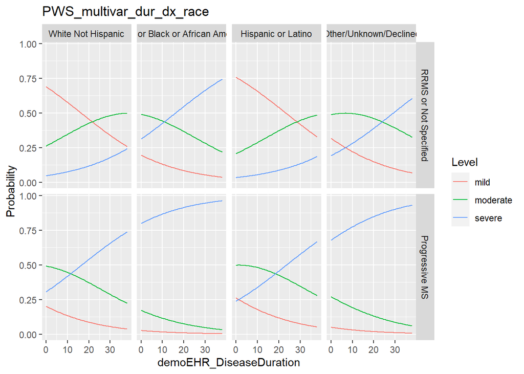

```r
# plot all of the predicted probabilities for the different conditions.
# example
#ggplot(lnewdat, aes(x = gpa, y = Probability, colour = Level)) +
  #geom_line() + facet_grid(pared ~ public, labeller="label_both")

p <- ggplot(lnewdat, aes(x = demoEHR_DiseaseDuration, y = Probability, colour = Level)) +
  geom_line() +
  facet_grid(ms_dx_condensed_2 ~ race_ethnicity_clean_2) +
  labs(title = filename)
p
```

```r
ggsave(file.path(output_dir, paste(filename, "probabilities.png", sep = "_")))
```

Plot 2 - Sig predictors in adjusted model Race, MS DX, and Log Pixel Proxy

```r
filename = "PWS_multivar_logPix_dx_race"

# model
pws_multivar_logPixdx_race <- polr(edss_severity_cat ~ log_delta_pix_h_rel_median_pose_zv +
                              ms_dx_condensed_2 +
                              race_ethnicity_clean_2,
                            data = zeno_pws_edss_df, Hess=TRUE)


summary_calc_p_and_odds(polr_object = pws_multivar_logPixdx_race,
                        file_name = filename)
```

```
## Call:
## polr(formula = edss_severity_cat ~ log_delta_pix_h_rel_median_pose_zv +
##     ms_dx_condensed_2 + race_ethnicity_clean_2, data = zeno_pws_edss_df,
##     Hess = TRUE)
##
## Coefficients:
##                                                             Value Std. Error
## log_delta_pix_h_rel_median_pose_zv                       -1.37995     0.5984
## ms_dx_condensed_2Progressive MS                           1.85280     0.6204
## race_ethnicity_clean_2Asian or Black or African American  2.31074     0.7197
## race_ethnicity_clean_2Hispanic or Latino                 -0.06854     0.7040
## race_ethnicity_clean_2Other/Unknown/Declined              1.20911     0.8696
##                                                           t value
## log_delta_pix_h_rel_median_pose_zv                       -2.30597
## ms_dx_condensed_2Progressive MS                           2.98656
## race_ethnicity_clean_2Asian or Black or African American  3.21072
## race_ethnicity_clean_2Hispanic or Latino                 -0.09736
## race_ethnicity_clean_2Other/Unknown/Declined              1.39042
##
## Intercepts:
##                 Value   Std. Error t value
## mild|moderate    2.0190  0.7798     2.5891
## moderate|severe  4.2358  0.8826     4.7991
##
## Residual Deviance: 175.2205
## AIC: 189.2205
## [1] "Add p-value"
##                                                                Value Std. Error
## log_delta_pix_h_rel_median_pose_zv                       -1.37994876  0.5984243
## ms_dx_condensed_2Progressive MS                           1.85280276  0.6203800
## race_ethnicity_clean_2Asian or Black or African American  2.31074310  0.7196969
## race_ethnicity_clean_2Hispanic or Latino                 -0.06854197  0.7039956
## race_ethnicity_clean_2Other/Unknown/Declined              1.20911036  0.8696037
## mild|moderate                                             2.01903211  0.7798312
## moderate|severe                                           4.23579460  0.8826288
##                                                              t value
## log_delta_pix_h_rel_median_pose_zv                       -2.30597040
## ms_dx_condensed_2Progressive MS                           2.98656095
## race_ethnicity_clean_2Asian or Black or African American  3.21071701
## race_ethnicity_clean_2Hispanic or Latino                 -0.09736137
## race_ethnicity_clean_2Other/Unknown/Declined              1.39041541
## mild|moderate                                             2.58906312
## moderate|severe                                           4.79906673
##                                                               p.value
## log_delta_pix_h_rel_median_pose_zv                       2.111229e-02
## ms_dx_condensed_2Progressive MS                          2.821346e-03
## race_ethnicity_clean_2Asian or Black or African American 1.324043e-03
## race_ethnicity_clean_2Hispanic or Latino                 9.224394e-01
## race_ethnicity_clean_2Other/Unknown/Declined             1.644028e-01
## mild|moderate                                            9.623745e-03
## moderate|severe                                          1.594067e-06
```

```
## [1] -2.609553
## [1] "Odds Ratio and CI"
##                                                                  OR    ci_2.5%
## log_delta_pix_h_rel_median_pose_zv                        0.2515914 0.07356742
## ms_dx_condensed_2Progressive MS                           6.3776696 0.07356742
## race_ethnicity_clean_2Asian or Black or African American 10.0819138 0.07356742
## race_ethnicity_clean_2Hispanic or Latino                  0.9337543 0.07356742
## race_ethnicity_clean_2Other/Unknown/Declined              3.3505026 0.07356742
##                                                          ci_97.5%
## log_delta_pix_h_rel_median_pose_zv                       1.942355
## ms_dx_condensed_2Progressive MS                          1.942355
## race_ethnicity_clean_2Asian or Black or African American 1.942355
## race_ethnicity_clean_2Hispanic or Latino                 1.942355
## race_ethnicity_clean_2Other/Unknown/Declined             1.942355
```

```
## as.numeric(edss_severity_cat)      N= 101
##
## +----------------------------------+----------------------------------+---+----+----+----------+
## |                                  |                                  |  N|Y>=1|Y>=2|      Y>=3|
## +----------------------------------+----------------------------------+---+----+----+----------+
## |log_delta_pix_h_rel_median_pose_zv|                   [-2.813,-1.470)| 26| Inf|   0|-1.3086838|
## |                                  |                   [-1.470,-1.204)| 25| Inf|   0|-1.7917595|
## |                                  |                   [-1.204,-0.994)| 27| Inf|   0|-2.4516207|
## |                                  |                   [-0.994,-0.462]| 23| Inf|   0|-2.4624338|
## +----------------------------------+----------------------------------+---+----+----+----------+
## |                 ms_dx_condensed_2|             RRMS or Not Specified| 85| Inf|   0|-1.7883868|
## |                                  |                    Progressive MS| 16| Inf|   0|-2.7080502|
## +----------------------------------+----------------------------------+---+----+----+----------+
## |            race_ethnicity_clean_2|                White Not Hispanic| 73| Inf|   0|-2.0438966|
## |                                  |Asian or Black or African American| 11| Inf|   0|-1.3217558|
## |                                  |                Hispanic or Latino| 11| Inf|   0|-0.9444616|
## |                                  |            Other/Unknown/Declined|  6| Inf|   0|-1.3862944|
## +----------------------------------+----------------------------------+---+----+----+----------+
## |                           Overall|                                  |101| Inf|   0|-1.6409721|
## +----------------------------------+----------------------------------+---+----+----+----------+
```

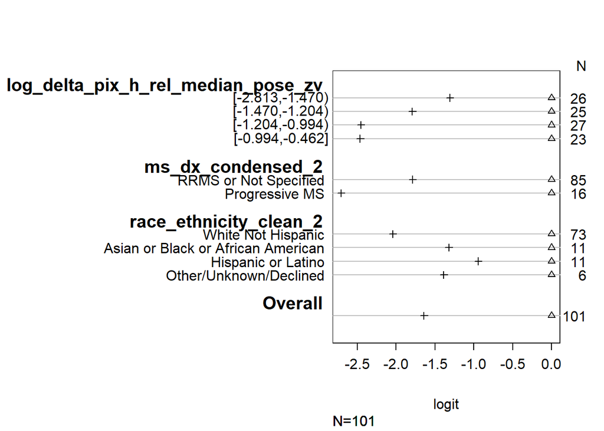

```r
# calculate the log odds of being greater than or equal to each value of the target variable
s <- with(zeno_pws_edss_df, summary(as.numeric(edss_severity_cat) ~ log_delta_pix_h_rel_median_pose_zv +
                                      ms_dx_condensed_2 +
                                      race_ethnicity_clean_2,
                                    fun=sf))
plot_check_assumption(s)
```

```r
# save original levels to create df
ms_dx_levels <- levels(pws_multivar_logPixdx_race$model$ms_dx_condensed_2)
ms_dx_levels
```

```
## [1] "RRMS or Not Specified" "Progressive MS"
```

```r
race_levels <- levels(pws_multivar_logPixdx_race$model$race_ethnicity_clean_2)
race_levels
```

```
## [1] "White Not Hispanic"                 "Asian or Black or African American"
## [3] "Hispanic or Latino"                 "Other/Unknown/Declined"
```

```r
# Define continuous variable ranges
log_pix_values <- seq(from = -2.813, to = -0.462, length.out = 100)

# Generate all combinations of categorical variables
cat_combinations <- expand.grid(
  ms_dx_condensed_2 = ms_dx_levels,
  race_ethnicity_clean_2 = race_levels,
  stringsAsFactors = TRUE  # Ensures they are factors
)

head(cat_combinations)
```

```
##       ms_dx_condensed_2             race_ethnicity_clean_2
## 1 RRMS or Not Specified                 White Not Hispanic
## 2        Progressive MS                 White Not Hispanic
## 3 RRMS or Not Specified Asian or Black or African American
## 4        Progressive MS Asian or Black or African American
## 5 RRMS or Not Specified                 Hispanic or Latino
## 6        Progressive MS                 Hispanic or Latino
```

```r
# Expand dataset to include all continuous variable values for each categorical combination
newdat <- expand.grid(
  log_delta_pix_h_rel_median_pose_zv = log_pix_values,
  stringsAsFactors = FALSE  # Keep continuous variables numeric
)

# Use `merge()` to properly combine categorical and continuous variables
newdat <- merge(cat_combinations, newdat, by = NULL)

# predict for each row of new dat using model
newdat <- cbind(newdat, predict(pws_multivar_logPixdx_race, newdat, type = "probs"))
head(newdat)
```

```
##       ms_dx_condensed_2             race_ethnicity_clean_2
## 1 RRMS or Not Specified                 White Not Hispanic
## 2        Progressive MS                 White Not Hispanic
## 3 RRMS or Not Specified Asian or Black or African American
## 4        Progressive MS Asian or Black or African American
## 5 RRMS or Not Specified                 Hispanic or Latino
## 6        Progressive MS                 Hispanic or Latino
##   log_delta_pix_h_rel_median_pose_zv        mild  moderate    severe
## 1                             -2.813 0.134381238 0.4532057 0.4124131
## 2                             -2.813 0.023763211 0.1588408 0.8173960
## 3                             -2.813 0.015164658 0.1086552 0.8761802
## 4                             -2.813 0.002408572 0.0192693 0.9783221
## 5                             -2.813 0.142555899 0.4615352 0.3959089
## 6                             -2.813 0.025406274 0.1676516 0.8069421
```

```r
head(newdat)
```

```
##       ms_dx_condensed_2             race_ethnicity_clean_2
## 1 RRMS or Not Specified                 White Not Hispanic
## 2        Progressive MS                 White Not Hispanic
## 3 RRMS or Not Specified Asian or Black or African American
## 4        Progressive MS Asian or Black or African American
## 5 RRMS or Not Specified                 Hispanic or Latino
## 6        Progressive MS                 Hispanic or Latino
##   log_delta_pix_h_rel_median_pose_zv        mild  moderate    severe
## 1                             -2.813 0.134381238 0.4532057 0.4124131
## 2                             -2.813 0.023763211 0.1588408 0.8173960
## 3                             -2.813 0.015164658 0.1086552 0.8761802
## 4                             -2.813 0.002408572 0.0192693 0.9783221
## 5                             -2.813 0.142555899 0.4615352 0.3959089
## 6                             -2.813 0.025406274 0.1676516 0.8069421
```

```r
# reshape for plotting
lnewdat <- melt(newdat, id.vars = c("log_delta_pix_h_rel_median_pose_zv",
                                    "ms_dx_condensed_2",
                                    "race_ethnicity_clean_2"),
                variable.name = "Level", value.name="Probability")
head(lnewdat)
```

```
##   log_delta_pix_h_rel_median_pose_zv     ms_dx_condensed_2
## 1                             -2.813 RRMS or Not Specified
## 2                             -2.813        Progressive MS
## 3                             -2.813 RRMS or Not Specified
## 4                             -2.813        Progressive MS
## 5                             -2.813 RRMS or Not Specified
## 6                             -2.813        Progressive MS
##               race_ethnicity_clean_2 Level Probability
## 1                 White Not Hispanic  mild 0.134381238
## 2                 White Not Hispanic  mild 0.023763211
## 3 Asian or Black or African American  mild 0.015164658
## 4 Asian or Black or African American  mild 0.002408572
## 5                 Hispanic or Latino  mild 0.142555899
## 6                 Hispanic or Latino  mild 0.025406274
```

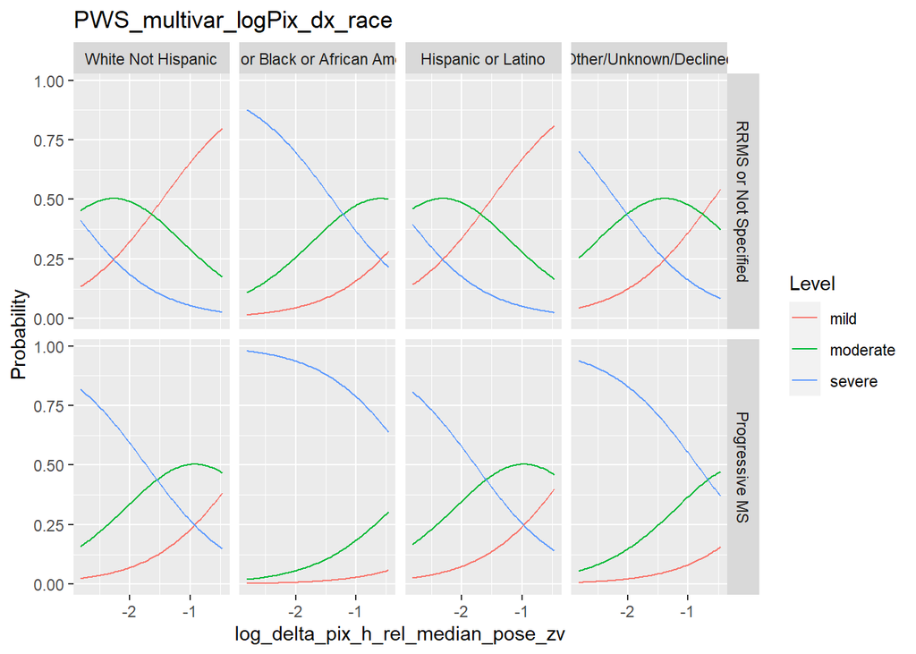

```r
# plot all of the predicted probabilities for the different conditions.
# example
#ggplot(lnewdat, aes(x = gpa, y = Probability, colour = Level)) +
  #geom_line() + facet_grid(pared ~ public, labeller="label_both")

p <- ggplot(lnewdat, aes(x = log_delta_pix_h_rel_median_pose_zv, y = Probability, colour = Level)) +
  geom_line() +
  facet_grid(ms_dx_condensed_2 ~ race_ethnicity_clean_2) +
  labs(title = filename)
p
```

```r
ggsave(file.path(output_dir, paste(filename, "probabilities.png", sep = "_")))
```

# Fast Walking Speed Videos

### Univariate - log pixel proxy

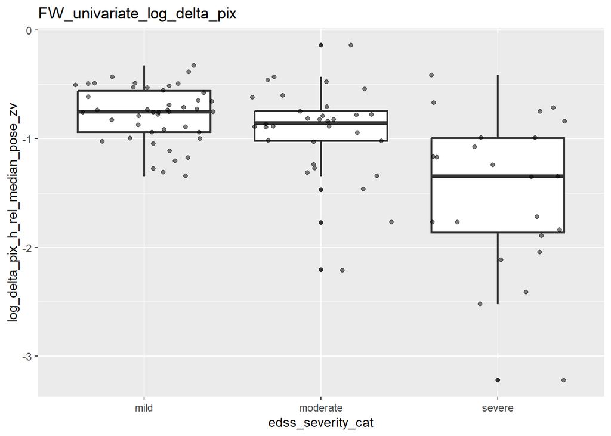

```r
# file name
filename = "FW_univariate_log_delta_pix"
# plot
ggplot(zeno_fw_edss_df, aes(x = edss_severity_cat, y = log_delta_pix_h_rel_median_pose_zv)) +
  geom_boxplot(size = .75) +
  geom_jitter(alpha = .5) +
  labs(title = filename)
```

```r
ggsave(file.path(output_dir, paste(filename, 'vs_edss.png', sep = "_")))
# model
uni1 <- polr(edss_severity_cat ~ log_delta_pix_h_rel_median_pose_zv,
             data = zeno_fw_edss_df, Hess=TRUE)

summary_calc_p_and_odds(polr_object = uni1,
                        file_name = filename)
```

```
## Call:
## polr(formula = edss_severity_cat ~ log_delta_pix_h_rel_median_pose_zv,
##     data = zeno_fw_edss_df, Hess = TRUE)
##
## Coefficients:
##                                     Value Std. Error t value
## log_delta_pix_h_rel_median_pose_zv -2.407     0.5173  -4.653
##
## Intercepts:
##                 Value   Std. Error t value
## mild|moderate    1.9906  0.5092     3.9093
## moderate|severe  3.7941  0.6201     6.1184
##
## Residual Deviance: 182.6804
## AIC: 188.6804
## [1] "Add p-value"
##                                        Value Std. Error   t value      p.value
## log_delta_pix_h_rel_median_pose_zv -2.407060  0.5172958 -4.653161 3.268849e-06
## mild|moderate                       1.990585  0.5091954  3.909274 9.257382e-05
## moderate|severe                     3.794051  0.6201034  6.118416 9.451009e-10
```

```
##     2.5 %
## -3.498312
## [1] "Odds Ratio and CI"
##                                           OR    ci_2.5%  ci_97.5%
## log_delta_pix_h_rel_median_pose_zv 0.0900797 0.03024839 0.2322903
```

If significant effect: Test proportional odds assumption

```
## as.numeric(edss_severity_cat)      N= 100
##
## +----------------------------------+---------------+---+----+----+---------+
## |                                  |               |  N|Y>=1|Y>=2|     Y>=3|
## +----------------------------------+---------------+---+----+----+---------+
## |log_delta_pix_h_rel_median_pose_zv|[-3.219,-1.109)| 27| Inf|   0|-1.258461|
## |                                  |[-1.109,-0.821)| 24| Inf|   0|-1.945910|
## |                                  |[-0.821,-0.673)| 24| Inf|   0|-2.061423|
## |                                  |[-0.673,-0.139]| 25| Inf|   0|-1.866983|
## +----------------------------------+---------------+---+----+----+---------+
## |                           Overall|               |100| Inf|   0|-1.408982|
## +----------------------------------+---------------+---+----+----+---------+
```

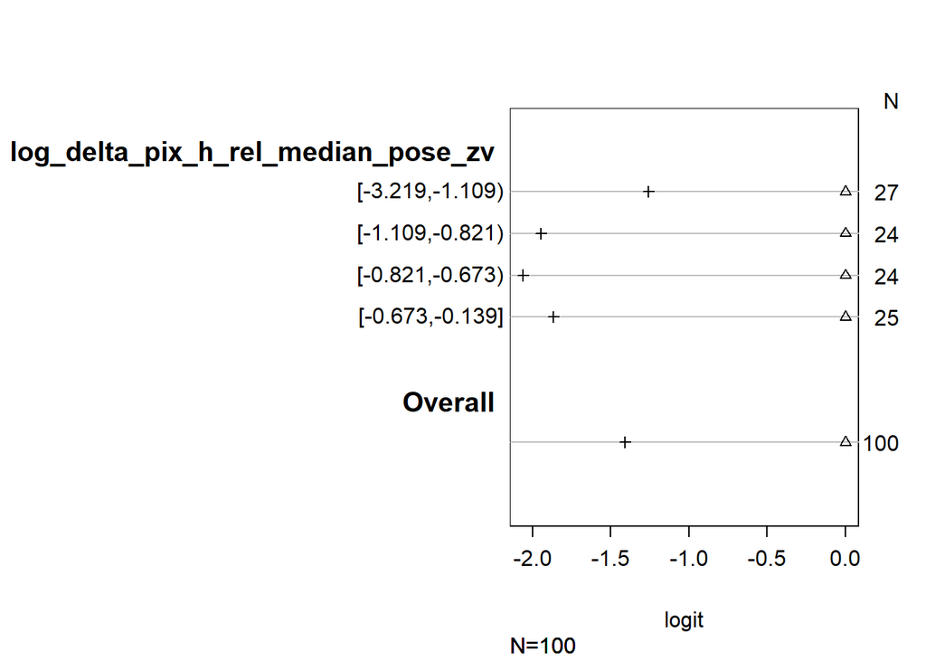

```r
# calculate the log odds of being greater than or equal to each value of the target variable
s <- with(zeno_fw_edss_df, summary(as.numeric(edss_severity_cat) ~ log_delta_pix_h_rel_median_pose_zv, fun=sf))
p <- plot_check_assumption(s_var = s)
```

```r
# Create new dataset of all values to use for prediction
newdat <- data.frame(
  log_delta_pix_h_rel_median_pose_zv = rep(seq(from = -3.219, to = -0.139, length.out = 100), 4))

# predict for each row of new dat using model
newdat <- cbind(newdat, predict(uni1, newdat, type = "probs"))
head(newdat)
```

```
##   log_delta_pix_h_rel_median_pose_zv        mild   moderate    severe
## 1                          -3.219000 0.003148288 0.01566356 0.9811881
## 2                          -3.187889 0.003392274 0.01685280 0.9797549
## 3                          -3.156778 0.003655098 0.01812997 0.9782149
## 4                          -3.125667 0.003938206 0.01950120 0.9765606
## 5                          -3.094556 0.004243147 0.02097299 0.9747839
## 6                          -3.063444 0.004571593 0.02255220 0.9728762
```

```r
# reshape for plotting
lnewdat <- melt(newdat, id.vars = c("log_delta_pix_h_rel_median_pose_zv"),
                variable.name = "Level", value.name="Probability")
head(lnewdat)
```

```
##   log_delta_pix_h_rel_median_pose_zv Level Probability
## 1                          -3.219000  mild 0.003148288
## 2                          -3.187889  mild 0.003392274
## 3                          -3.156778  mild 0.003655098
## 4                          -3.125667  mild 0.003938206
## 5                          -3.094556  mild 0.004243147
## 6                          -3.063444  mild 0.004571593
```

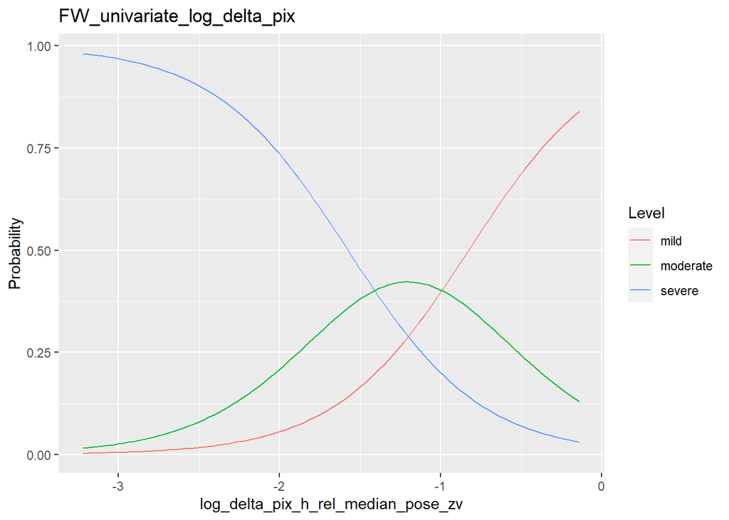

```r
# plot all of the predicted probabilities for the different conditions.
# example
#ggplot(lnewdat, aes(x = gpa, y = Probability, colour = Level)) +
  #geom_line() + facet_grid(pared ~ public, labeller="label_both")

p <- ggplot(lnewdat, aes(x = log_delta_pix_h_rel_median_pose_zv, y = Probability, colour = Level)) +
  geom_line() +
  labs(title = filename) +
  labs(title = filename)
p
```

```r
ggsave(file.path(output_dir, paste(filename, "probabilities.png", sep = "_")))
```

### Univariate - stride_time_median_sec_pose

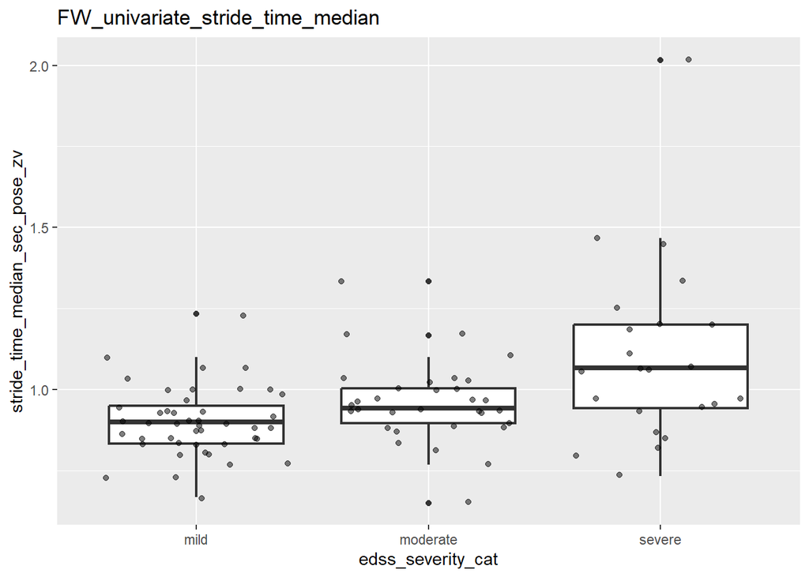

```r
filename = "FW_univariate_stride_time_median"
# plot
ggplot(zeno_fw_edss_df, aes(x = edss_severity_cat, y = stride_time_median_sec_pose_zv)) +
  geom_boxplot(size = .75) +
  geom_jitter(alpha = .5) +
  labs(title = filename)
```

```r
ggsave(file.path(output_dir, paste(filename, 'vs_edss.png', sep = "_")))
# model
uni1 <- polr(edss_severity_cat ~ stride_time_median_sec_pose_zv,
             data = zeno_fw_edss_df, Hess=TRUE)

summary_calc_p_and_odds(polr_object = uni1,
                        file_name = filename)
```

```
## Call:
## polr(formula = edss_severity_cat ~ stride_time_median_sec_pose_zv,
##     data = zeno_fw_edss_df, Hess = TRUE)
##
## Coefficients:
##                                Value Std. Error t value
## stride_time_median_sec_pose_zv 6.032      1.528   3.948
##
## Intercepts:
##                 Value  Std. Error t value
## mild|moderate   5.5138 1.4574     3.7833
## moderate|severe 7.1840 1.5364     4.6759
##
## Residual Deviance: 191.1905
## AIC: 197.1905
## [1] "Add p-value"
##                                   Value Std. Error  t value      p.value
## stride_time_median_sec_pose_zv 6.031530   1.527752 3.947978 7.881388e-05
## mild|moderate                  5.513827   1.457415 3.783293 1.547668e-04
## moderate|severe                7.184026   1.536379 4.675946 2.926019e-06
```

```
##    2.5 %
## 3.230702
## [1] "Odds Ratio and CI"
##                                      OR ci_2.5% ci_97.5%
## stride_time_median_sec_pose_zv 416.3517 25.2974  10301.2
```

If significant effect: Test proportional odds assumption

```
## as.numeric(edss_severity_cat)      N= 100
##
## +------------------------------+-------------+---+----+----+---------+
## |                              |             |  N|Y>=1|Y>=2|     Y>=3|
## +------------------------------+-------------+---+----+----+---------+
## |stride_time_median_sec_pose_zv|[0.650,0.883)| 29| Inf|   0|-0.926762|
## |                              |[0.883,0.950)| 26| Inf|   0|-3.064725|
## |                              |[0.950,1.033)| 20| Inf|   0|-2.005334|
## |                              |[1.033,2.017]| 25| Inf|   0|-1.306252|
## +------------------------------+-------------+---+----+----+---------+
## |                       Overall|             |100| Inf|   0|-1.408982|
## +------------------------------+-------------+---+----+----+---------+
```

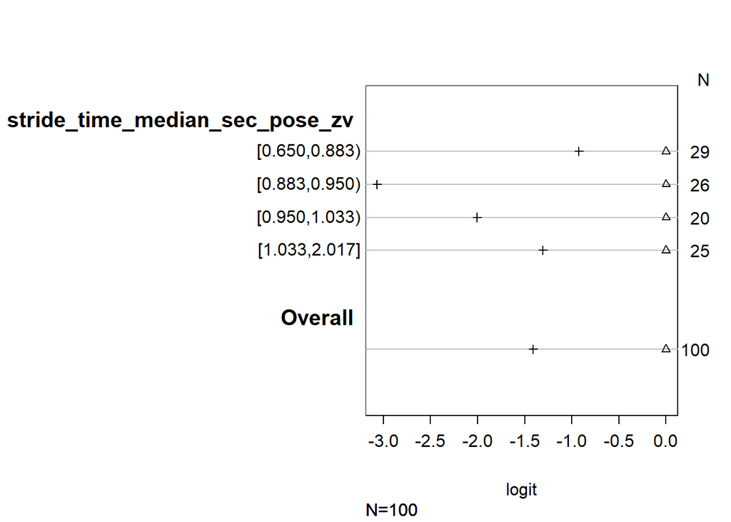

```r
# calculate the log odds of being greater than or equal to each value of the target variable
s <- with(zeno_fw_edss_df, summary(as.numeric(edss_severity_cat) ~ stride_time_median_sec_pose_zv, fun=sf))
p <- plot_check_assumption(s_var = s)
```

```r
# Create new dataset of all values to use for prediction
newdat <- data.frame(
  stride_time_median_sec_pose_zv = rep(seq(from = 0.650, to = 2.017, length.out = 100), 4))

# predict for each row of new dat using model
newdat <- cbind(newdat, predict(uni1, newdat, type = "probs"))
head(newdat)
```

```
##   stride_time_median_sec_pose_zv      mild  moderate     severe
## 1                      0.6500000 0.8310845 0.1320718 0.03684371
## 2                      0.6638081 0.8190684 0.1410157 0.03991587
## 3                      0.6776162 0.8063968 0.1503705 0.04323270
## 4                      0.6914242 0.7930618 0.1601265 0.04681170
## 5                      0.7052323 0.7790601 0.1702686 0.05067130
## 6                      0.7190404 0.7643924 0.1807768 0.05483082
```

```r
# reshape for plotting
lnewdat <- melt(newdat, id.vars = c("stride_time_median_sec_pose_zv"),
                variable.name = "Level", value.name="Probability")
head(lnewdat)
```

```
##   stride_time_median_sec_pose_zv Level Probability
## 1                      0.6500000  mild   0.8310845
## 2                      0.6638081  mild   0.8190684
## 3                      0.6776162  mild   0.8063968
## 4                      0.6914242  mild   0.7930618
## 5                      0.7052323  mild   0.7790601
## 6                      0.7190404  mild   0.7643924
```

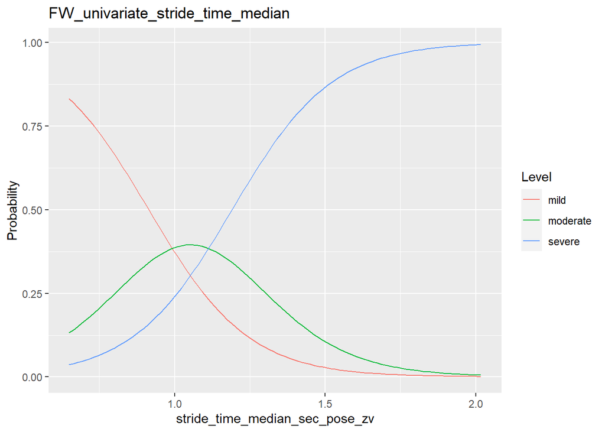

```r
# plot all of the predicted probabilities for the different conditions.
# example
#ggplot(lnewdat, aes(x = gpa, y = Probability, colour = Level)) +
  #geom_line() + facet_grid(pared ~ public, labeller="label_both")

p <- ggplot(lnewdat, aes(x = stride_time_median_sec_pose_zv, y = Probability, colour = Level)) +
  geom_line() +
  labs(title = filename)
p
```

```r
ggsave(file.path(output_dir, paste(filename, "probabilities.png", sep = "_")))
```

### Univariate - mean_cadence_step_per_min_pose

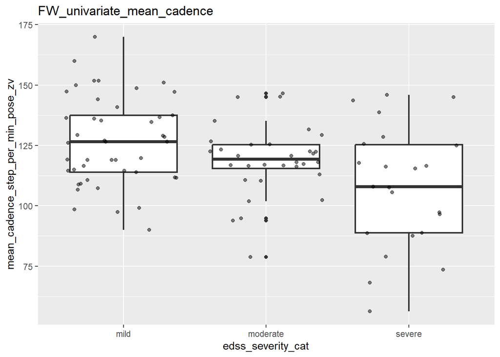

```r
filename = "FW_univariate_mean_cadence"
# plot
ggplot(zeno_fw_edss_df, aes(x = edss_severity_cat, y = mean_cadence_step_per_min_pose_zv)) +
  geom_boxplot(size = .75) +
  geom_jitter(alpha = .5) +
  labs(title = filename)
```

```r
ggsave(file.path(output_dir, paste(filename, 'vs_edss.png', sep = "_")))
# model
uni1 <- polr(edss_severity_cat ~ mean_cadence_step_per_min_pose_zv,
             data = zeno_fw_edss_df, Hess=TRUE)

summary_calc_p_and_odds(polr_object = uni1,
                        file_name = filename)
```

```
## Call:
## polr(formula = edss_severity_cat ~ mean_cadence_step_per_min_pose_zv,
##     data = zeno_fw_edss_df, Hess = TRUE)
##
## Coefficients:
##                                     Value Std. Error t value
## mean_cadence_step_per_min_pose_zv -0.0399    0.01085  -3.677
##
## Intercepts:
##                 Value   Std. Error t value
## mild|moderate   -5.0179  1.3218    -3.7962
## moderate|severe -3.4320  1.2715    -2.6992
##
## Residual Deviance: 197.2532
## AIC: 203.2532
## [1] "Add p-value"
##                                        Value Std. Error   t value      p.value
## mean_cadence_step_per_min_pose_zv -0.0399029 0.01085282 -3.676730 0.0002362426
## mild|moderate                     -5.0179361 1.32182795 -3.796210 0.0001469252
## moderate|severe                   -3.4319503 1.27147256 -2.699193 0.0069507770
```

```
##       2.5 %
## -0.06226445
## [1] "Odds Ratio and CI"
##                                          OR   ci_2.5%  ci_97.5%
## mean_cadence_step_per_min_pose_zv 0.9608827 0.9396344 0.9807872
```

If significant effect: Test proportional odds assumption

```
## as.numeric(edss_severity_cat)      N= 100
##
## +---------------------------------+-----------+---+----+----+----------+
## |                                 |           |  N|Y>=1|Y>=2|      Y>=3|
## +---------------------------------+-----------+---+----+----+----------+
## |mean_cadence_step_per_min_pose_zv|[ 56.4,110)| 25| Inf|   0|-0.8338145|
## |                                 |[110.4,119)| 25| Inf|   0|-2.0636932|
## |                                 |[119.0,135)| 25| Inf|   0|-2.3978953|
## |                                 |[134.7,170]| 25| Inf|   0|-0.9044563|
## +---------------------------------+-----------+---+----+----+----------+
## |                          Overall|           |100| Inf|   0|-1.4089819|
## +---------------------------------+-----------+---+----+----+----------+
```

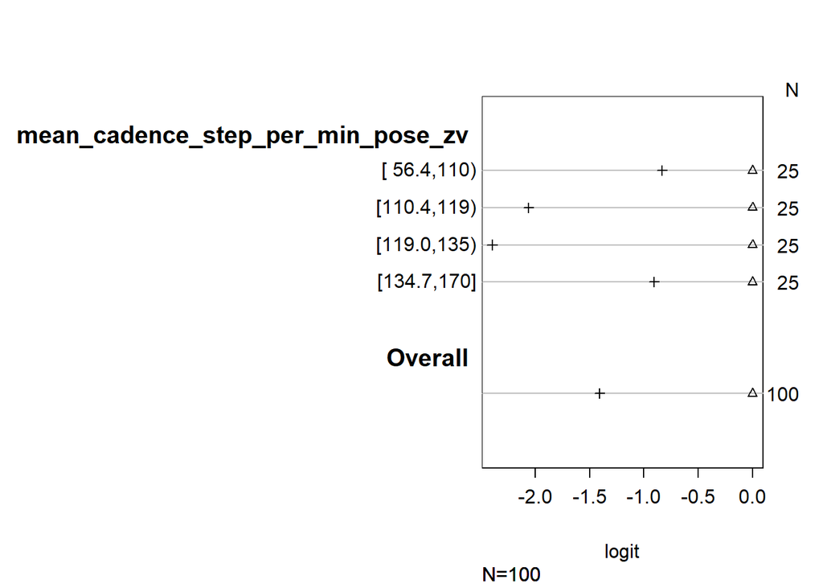

```r
# calculate the log odds of being greater than or equal to each value of the target variable
s <- with(zeno_fw_edss_df, summary(as.numeric(edss_severity_cat) ~ mean_cadence_step_per_min_pose_zv, fun=sf))
p <- plot_check_assumption(s_var = s)
```

```r
# Create new dataset of all values to use for prediction
newdat <- data.frame(
  mean_cadence_step_per_min_pose_zv = rep(seq(from = 56.4, to = 170, length.out = 100), 4))

# predict for each row of new dat using model
newdat <- cbind(newdat, predict(uni1, newdat, type = "probs"))
head(newdat)
```

```
##   mean_cadence_step_per_min_pose_zv       mild  moderate    severe
## 1                          56.40000 0.05911076 0.1756850 0.7652042
## 2                          57.54747 0.06170932 0.1814126 0.7568781
## 3                          58.69495 0.06441429 0.1872320 0.7483538
## 4                          59.84242 0.06722933 0.1931373 0.7396334
## 5                          60.98990 0.07015818 0.1991223 0.7307196
## 6                          62.13737 0.07320460 0.2051800 0.7216154
```

```r
# reshape for plotting
lnewdat <- melt(newdat, id.vars = c("mean_cadence_step_per_min_pose_zv"),
                variable.name = "Level", value.name="Probability")
head(lnewdat)
```

```
##   mean_cadence_step_per_min_pose_zv Level Probability
## 1                          56.40000  mild  0.05911076
## 2                          57.54747  mild  0.06170932
## 3                          58.69495  mild  0.06441429
## 4                          59.84242  mild  0.06722933
## 5                          60.98990  mild  0.07015818
## 6                          62.13737  mild  0.07320460
```

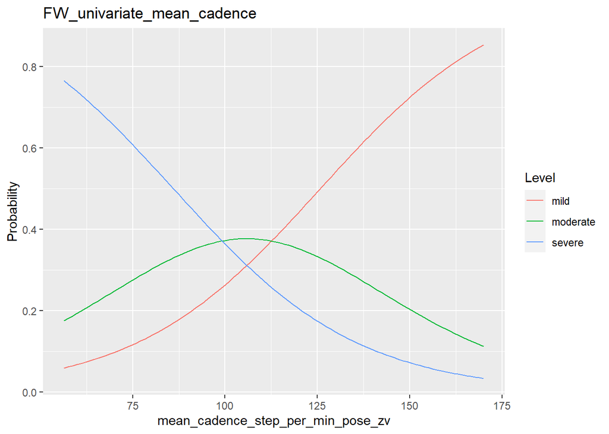

```r
# plot all of the predicted probabilities for the different conditions.
# example
#ggplot(lnewdat, aes(x = gpa, y = Probability, colour = Level)) +
  #geom_line() + facet_grid(pared ~ public, labeller="label_both")

p <- ggplot(lnewdat, aes(x = mean_cadence_step_per_min_pose_zv, y = Probability, colour = Level)) +
  geom_line() +
  labs(title = filename)
p
```

```r
ggsave(file.path(output_dir, paste(filename, "probabilities.png", sep = "_")))
```

### Univariate - stride_width_median_cm_pose

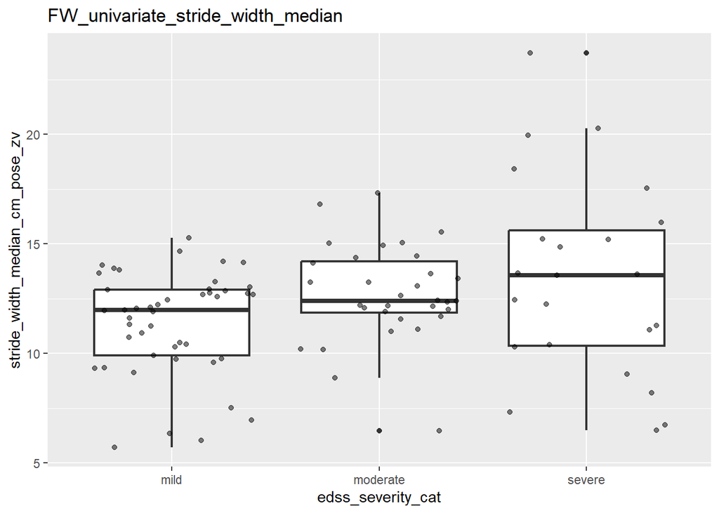

```r
filename = "FW_univariate_stride_width_median"
# plot
ggplot(zeno_fw_edss_df, aes(x = edss_severity_cat, y = stride_width_median_cm_pose_zv)) +
  geom_boxplot(size = .75) +
  geom_jitter(alpha = .5) +
  labs(title = filename)
```

```r
ggsave(file.path(output_dir, paste(filename, 'vs_edss.png', sep = "_")))
# model
uni1 <- polr(edss_severity_cat ~ stride_width_median_cm_pose_zv,
             data = zeno_fw_edss_df, Hess=TRUE)

summary_calc_p_and_odds(polr_object = uni1,
                        file_name = filename)
```

```
## Call:
## polr(formula = edss_severity_cat ~ stride_width_median_cm_pose_zv,
##     data = zeno_fw_edss_df, Hess = TRUE)
##
## Coefficients:
##                                 Value Std. Error t value
## stride_width_median_cm_pose_zv 0.2012    0.07068   2.847
##
## Intercepts:
##                 Value  Std. Error t value
## mild|moderate   2.2733 0.8990     2.5288
## moderate|severe 3.7879 0.9533     3.9734
##
## Residual Deviance: 203.6172
## AIC: 209.6172
## [1] "Add p-value"
##                                    Value Std. Error  t value      p.value
## stride_width_median_cm_pose_zv 0.2012199 0.07068027 2.846903 4.414683e-03
## mild|moderate                  2.2733025 0.89895864 2.528818 1.144475e-02
## moderate|severe                3.7879228 0.95331698 3.973414 7.084982e-05
```

```
##      2.5 %
## 0.06707791
## [1] "Odds Ratio and CI"
##                                      OR  ci_2.5% ci_97.5%
## stride_width_median_cm_pose_zv 1.222894 1.069379 1.414771
```

If significant effect: Test proportional odds assumption

```
## as.numeric(edss_severity_cat)      N= 100
##
## +------------------------------+------------+---+----+----+----------+
## |                              |            |  N|Y>=1|Y>=2|      Y>=3|
## +------------------------------+------------+---+----+----+----------+
## |stride_width_median_cm_pose_zv|[ 5.72,10.5)| 25| Inf|   0|-0.7032996|
## |                              |[10.49,12.4)| 25| Inf|   0|-2.0724729|
## |                              |[12.35,13.8)| 25| Inf|   0|-1.7382708|
## |                              |[13.81,23.7]| 25| Inf|   0|-1.5198258|
## +------------------------------+------------+---+----+----+----------+
## |                       Overall|            |100| Inf|   0|-1.4089819|
## +------------------------------+------------+---+----+----+----------+
```

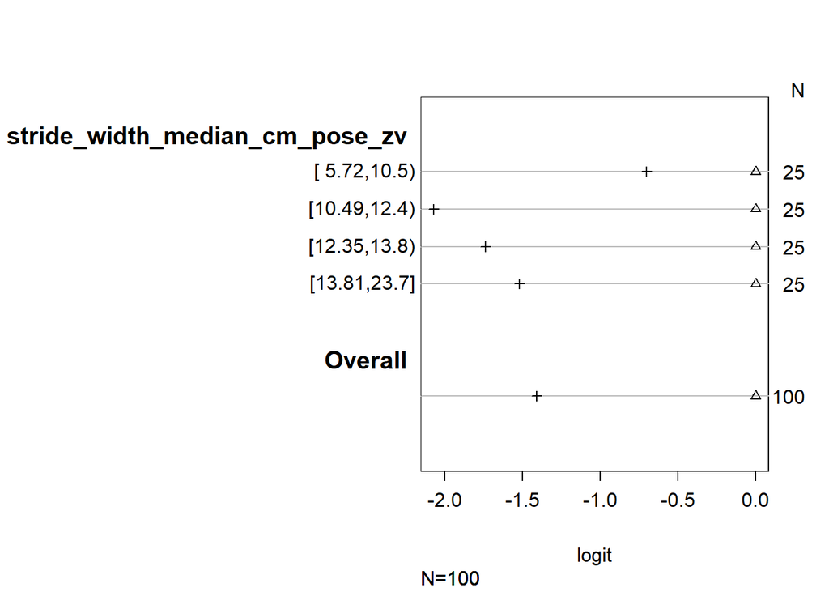

```r
# calculate the log odds of being greater than or equal to each value of the target variable
s <- with(zeno_fw_edss_df, summary(as.numeric(edss_severity_cat) ~ stride_width_median_cm_pose_zv, fun=sf))
p <- plot_check_assumption(s_var = s)
```

```r
# Create new dataset of all values to use for prediction
newdat <- data.frame(
  stride_width_median_cm_pose_zv = rep(seq(from = 5.72, to = 23.7, length.out = 100), 4))

# predict for each row of new dat using model
newdat <- cbind(newdat, predict(uni1, newdat, type = "probs"))
head(newdat)
```

```
##   stride_width_median_cm_pose_zv      mild  moderate     severe
## 1                       5.720000 0.7544197 0.1787821 0.06679821
## 2                       5.901616 0.7475862 0.1833011 0.06911266
## 3                       6.083232 0.7406280 0.1878708 0.07150115
## 4                       6.264848 0.7335464 0.1924880 0.07396563
## 5                       6.446465 0.7263428 0.1971492 0.07650806
## 6                       6.628081 0.7190190 0.2018506 0.07913041
```

```r
# reshape for plotting
lnewdat <- melt(newdat, id.vars = c("stride_width_median_cm_pose_zv"),
                variable.name = "Level", value.name="Probability")
head(lnewdat)
```

```
##   stride_width_median_cm_pose_zv Level Probability
## 1                       5.720000  mild   0.7544197
## 2                       5.901616  mild   0.7475862
## 3                       6.083232  mild   0.7406280
## 4                       6.264848  mild   0.7335464
## 5                       6.446465  mild   0.7263428
## 6                       6.628081  mild   0.7190190
```

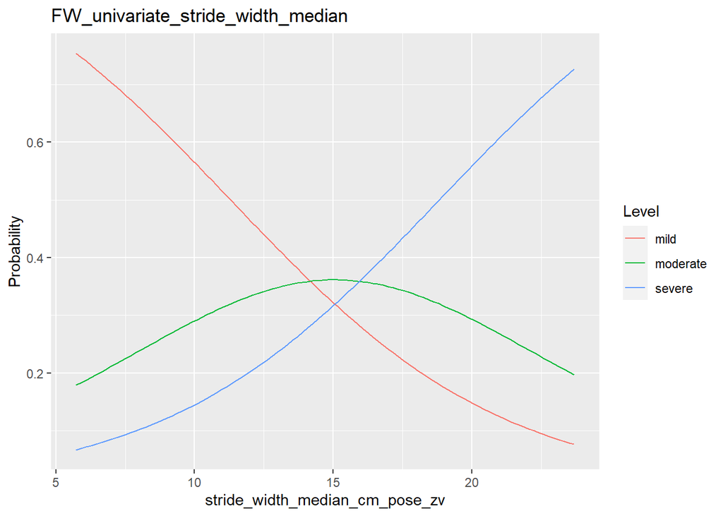

```r
# plot all of the predicted probabilities for the different conditions.
# example
#ggplot(lnewdat, aes(x = gpa, y = Probability, colour = Level)) +
  #geom_line() + facet_grid(pared ~ public, labeller="label_both")

p <- ggplot(lnewdat, aes(x = stride_width_median_cm_pose_zv, y = Probability, colour = Level)) +
  geom_line() +
  labs(title = filename)
p
```

```r
ggsave(file.path(output_dir, paste(filename, "probabilities.png", sep = "_")))
```

### Univariate - demoEHR_Age

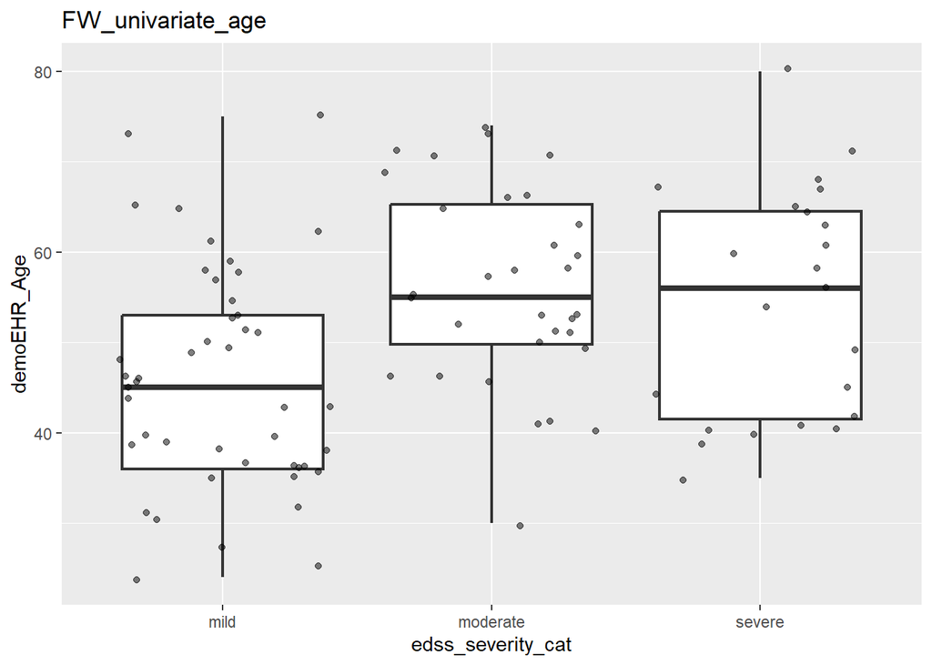

```r
filename = "FW_univariate_age"
# plot
ggplot(zeno_fw_edss_df, aes(x = edss_severity_cat, y = demoEHR_Age)) +
  geom_boxplot(size = .75) +
  geom_jitter(alpha = .5) +
  labs(title = filename)
```

```r
ggsave(file.path(output_dir, paste(filename, 'vs_edss.png', sep = "_")))
# model
uni1 <- polr(edss_severity_cat ~ demoEHR_Age,
             data = zeno_fw_edss_df, Hess=TRUE)

summary_calc_p_and_odds(polr_object = uni1,
                        file_name = filename)
```

```
## Call:
## polr(formula = edss_severity_cat ~ demoEHR_Age, data = zeno_fw_edss_df,
##     Hess = TRUE)
##
## Coefficients:
##               Value Std. Error t value
## demoEHR_Age 0.05179    0.01594   3.249
##
## Intercepts:
##                 Value  Std. Error t value
## mild|moderate   2.4617 0.8488     2.9001
## moderate|severe 4.0003 0.9076     4.4074
##
## Residual Deviance: 201.0321
## AIC: 207.0321
## [1] "Add p-value"
##                      Value Std. Error  t value      p.value
## demoEHR_Age     0.05178519 0.01593854 3.249054 0.0011578939
## mild|moderate   2.46167104 0.84881269 2.900135 0.0037300247
## moderate|severe 4.00025575 0.90762603 4.407383 0.0000104627
```

```
##      2.5 %
## 0.02132328
## [1] "Odds Ratio and CI"
##                   OR  ci_2.5% ci_97.5%
## demoEHR_Age 1.053149 1.021552 1.087744
```

If significant effect: Test proportional odds assumption

```
## as.numeric(edss_severity_cat)      N= 100
##
## +-----------+-------+---+----+----+----------+
## |           |       |  N|Y>=1|Y>=2|      Y>=3|
## +-----------+-------+---+----+----+----------+
## |demoEHR_Age|[24,41)| 26| Inf|   0|-0.4365557|
## |           |[41,52)| 27| Inf|   0|-1.5557125|
## |           |[52,62)| 24| Inf|   0|-2.0281482|
## |           |[62,80]| 23| Inf|   0|-1.9095425|
## +-----------+-------+---+----+----+----------+
## |    Overall|       |100| Inf|   0|-1.4089819|
## +-----------+-------+---+----+----+----------+
```

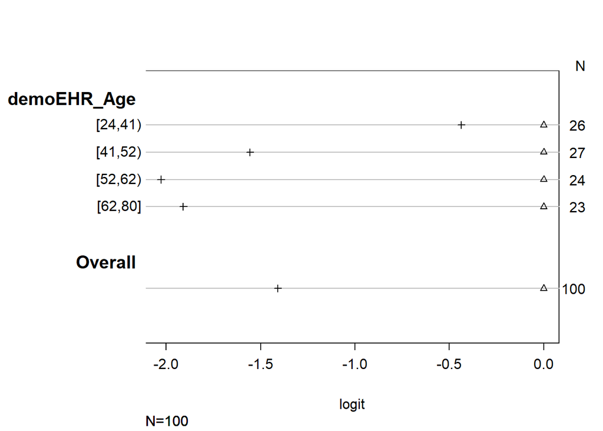

```r
# calculate the log odds of being greater than or equal to each value of the target variable
s <- with(zeno_fw_edss_df, summary(as.numeric(edss_severity_cat) ~ demoEHR_Age, fun=sf))
p <- plot_check_assumption(s_var = s)
```

```r
# Create new dataset of all values to use for prediction
newdat <- data.frame(
  demoEHR_Age = rep(seq(from = 24, to = 80, length.out = 100), 4))

# predict for each row of new dat using model
newdat <- cbind(newdat, predict(uni1, newdat, type = "probs"))
head(newdat)
```

```
##   demoEHR_Age      mild  moderate     severe
## 1    24.00000 0.7718570 0.1684736 0.05966946
## 2    24.56566 0.7666577 0.1720079 0.06133439
## 3    25.13131 0.7613765 0.1755808 0.06304267
## 4    25.69697 0.7560139 0.1791908 0.06479525
## 5    26.26263 0.7505702 0.1828367 0.06659308
## 6    26.82828 0.7450461 0.1865168 0.06843714
```

```r
# reshape for plotting
lnewdat <- melt(newdat, id.vars = c("demoEHR_Age"),
                variable.name = "Level", value.name="Probability")
head(lnewdat)
```

```
##   demoEHR_Age Level Probability
## 1    24.00000  mild   0.7718570
## 2    24.56566  mild   0.7666577
## 3    25.13131  mild   0.7613765
## 4    25.69697  mild   0.7560139
## 5    26.26263  mild   0.7505702
## 6    26.82828  mild   0.7450461
```

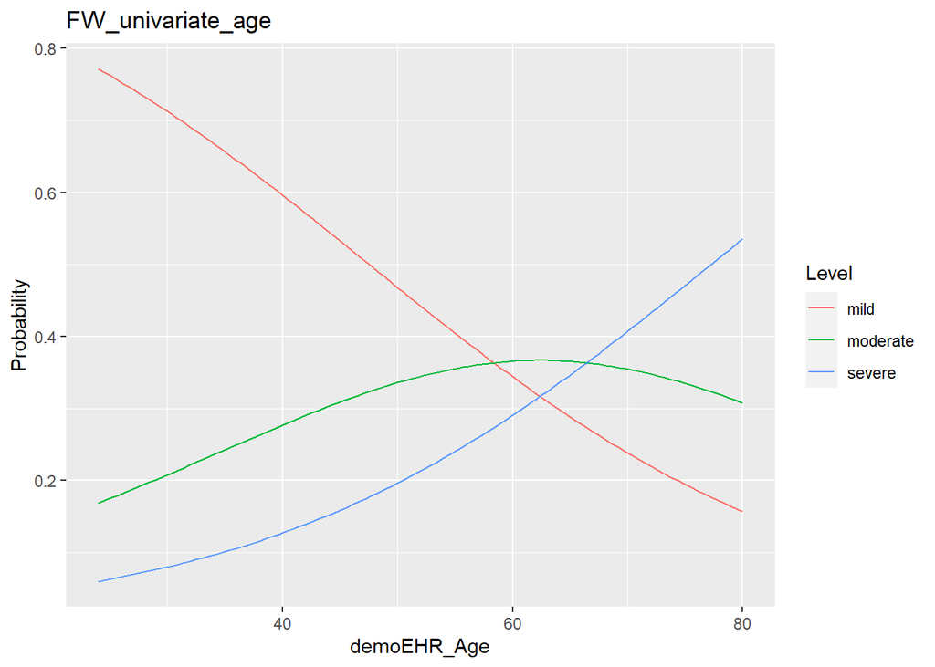

```r
# plot all of the predicted probabilities for the different conditions.
# example
#ggplot(lnewdat, aes(x = gpa, y = Probability, colour = Level)) +
  #geom_line() + facet_grid(pared ~ public, labeller="label_both")

p <- ggplot(lnewdat, aes(x = demoEHR_Age, y = Probability, colour = Level)) +
  geom_line() +
  labs(title = filename)
p
```

```r
ggsave(file.path(output_dir, paste(filename, "probabilities.png", sep = "_")))
```

### Univariate - demoEHR_DiseaseDuration

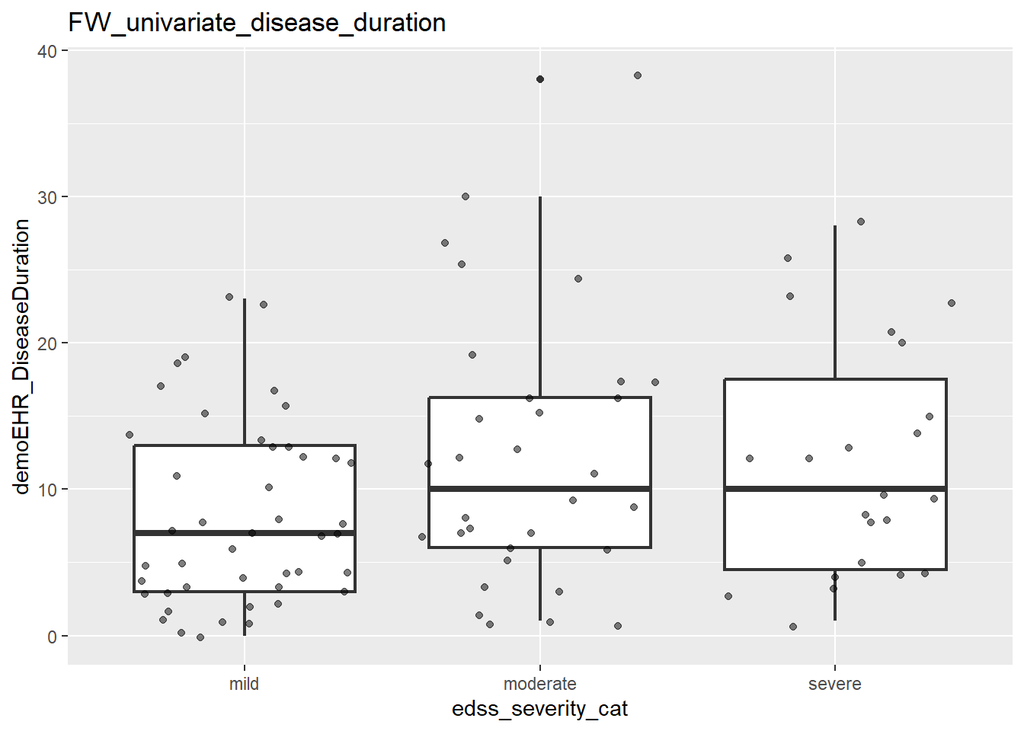

```r
filename = "FW_univariate_disease_duration"
# plot
ggplot(zeno_fw_edss_df, aes(x = edss_severity_cat, y = demoEHR_DiseaseDuration)) +
  geom_boxplot(size = .75) +
  geom_jitter(alpha = .5) +
  labs(title = filename)
```

```r
ggsave(file.path(output_dir, paste(filename, 'vs_edss.png', sep = "_")))
# model
uni1 <- polr(edss_severity_cat ~ demoEHR_DiseaseDuration,
             data = zeno_fw_edss_df, Hess=TRUE)

summary_calc_p_and_odds(polr_object = uni1,
                        file_name = filename)
```

```
## Call:
## polr(formula = edss_severity_cat ~ demoEHR_DiseaseDuration, data = zeno_fw_edss_df,
##     Hess = TRUE)
##
## Coefficients:
##                           Value Std. Error t value
## demoEHR_DiseaseDuration 0.04891    0.02336   2.094
##
## Intercepts:
##                 Value  Std. Error t value
## mild|moderate   0.3078 0.3168     0.9716
## moderate|severe 1.7697 0.3665     4.8282
##
## Residual Deviance: 207.8995
## AIC: 213.8995
## [1] "Add p-value"
##                              Value Std. Error   t value      p.value
## demoEHR_DiseaseDuration 0.04890947 0.02335944 2.0937774 3.627981e-02
## mild|moderate           0.30781223 0.31682437 0.9715548 3.312721e-01
## moderate|severe         1.76965624 0.36652185 4.8282422 1.377435e-06
```

```
##       2.5 %
## 0.003678677
## [1] "Odds Ratio and CI"
##                               OR  ci_2.5% ci_97.5%
## demoEHR_DiseaseDuration 1.050125 1.003685 1.100598
```

If significant effect: Test proportional odds assumption

```
## as.numeric(edss_severity_cat)      N= 100
##
## +-----------------------+-------+---+----+----+----------+
## |                       |       |  N|Y>=1|Y>=2|      Y>=3|
## +-----------------------+-------+---+----+----+----------+
## |demoEHR_DiseaseDuration|[ 0, 5)| 30| Inf|   0|-0.9808293|
## |                       |[ 5, 9)| 22| Inf|   0|-1.6863990|
## |                       |[ 9,16)| 25| Inf|   0|-1.3499267|
## |                       |[16,38]| 23| Inf|   0|-1.8681324|
## +-----------------------+-------+---+----+----+----------+
## |                Overall|       |100| Inf|   0|-1.4089819|
## +-----------------------+-------+---+----+----+----------+
```

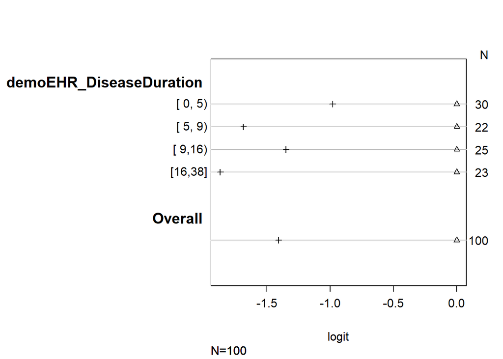

```r
# calculate the log odds of being greater than or equal to each value of the target variable
s <- with(zeno_fw_edss_df, summary(as.numeric(edss_severity_cat) ~ demoEHR_DiseaseDuration, fun=sf))
p <- plot_check_assumption(s_var = s)
```

```r
# Create new dataset of all values to use for prediction
newdat <- data.frame(
  demoEHR_DiseaseDuration = rep(seq(from = 0, to = 38, length.out = 100), 4))

# predict for each row of new dat using model
newdat <- cbind(newdat, predict(uni1, newdat, type = "probs"))
head(newdat)
```

```
##   demoEHR_DiseaseDuration      mild  moderate    severe
## 1               0.0000000 0.5763512 0.2780638 0.1455851
## 2               0.3838384 0.5717608 0.2803033 0.1479359
## 3               0.7676768 0.5671581 0.2825240 0.1503179
## 4               1.1515152 0.5625438 0.2847248 0.1527315
## 5               1.5353535 0.5579186 0.2869047 0.1551767
## 6               1.9191919 0.5532833 0.2890629 0.1576538
```

```r
# reshape for plotting
lnewdat <- melt(newdat, id.vars = c("demoEHR_DiseaseDuration"),
                variable.name = "Level", value.name="Probability")
head(lnewdat)
```

```
##   demoEHR_DiseaseDuration Level Probability
## 1               0.0000000  mild   0.5763512
## 2               0.3838384  mild   0.5717608
## 3               0.7676768  mild   0.5671581
## 4               1.1515152  mild   0.5625438
## 5               1.5353535  mild   0.5579186
## 6               1.9191919  mild   0.5532833
```

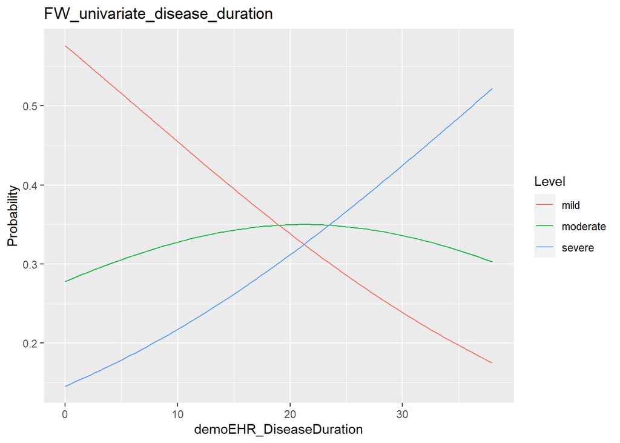

```r
# plot all of the predicted probabilities for the different conditions.
# example
#ggplot(lnewdat, aes(x = gpa, y = Probability, colour = Level)) +
  #geom_line() + facet_grid(pared ~ public, labeller="label_both")

p <- ggplot(lnewdat, aes(x = demoEHR_DiseaseDuration, y = Probability, colour = Level)) +
  geom_line() +
  labs(title = filename)
p
```

```r
ggsave(file.path(output_dir, paste(filename, "probabilities.png", sep = "_")))
```

### Univariate - ms_dx_condensed

Using two groups: RRMS and not specified, or progressive

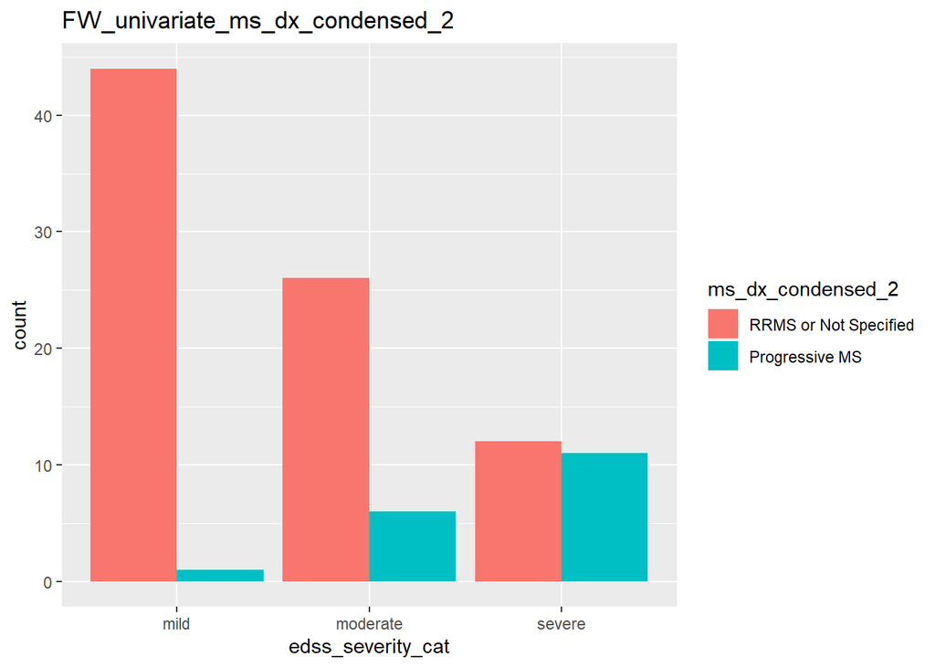

```r
filename = "FW_univariate_ms_dx_condensed_2"

# plot
ggplot(zeno_fw_edss_df, aes(x = edss_severity_cat, fill = ms_dx_condensed_2)) +
  geom_bar(position = "dodge")  +
  labs(title = filename)
```

```r
ggsave(file.path(output_dir, paste(filename, 'vs_edss.png', sep = "_")))
# model
uni1 <- polr(edss_severity_cat ~ ms_dx_condensed_2,
             data = zeno_fw_edss_df, Hess=TRUE)


summary_calc_p_and_odds(polr_object = uni1,
                        file_name = filename)
```

```
## Call:
## polr(formula = edss_severity_cat ~ ms_dx_condensed_2, data = zeno_fw_edss_df,
##     Hess = TRUE)
##
## Coefficients:
##                                 Value Std. Error t value
## ms_dx_condensed_2Progressive MS 2.359     0.5458   4.323
##
## Intercepts:
##                 Value  Std. Error t value
## mild|moderate   0.1277 0.2211     0.5777
## moderate|severe 1.8350 0.3082     5.9542
##
## Residual Deviance: 191.12
## AIC: 197.12
## [1] "Add p-value"
##                                     Value Std. Error   t value      p.value
## ms_dx_condensed_2Progressive MS 2.3593749  0.5458228 4.3226024 1.541994e-05
## mild|moderate                   0.1277412  0.2211086 0.5777305 5.634461e-01
## moderate|severe                 1.8350258  0.3081918 5.9541675 2.613990e-09
```

```
##    2.5 %
## 1.328862
## [1] "Odds Ratio and CI"
##                                       OR  ci_2.5% ci_97.5%
## ms_dx_condensed_2Progressive MS 10.58433 3.776741 32.70644
```

If significant effect: Test proportional odds assumption

```
## as.numeric(edss_severity_cat)      N= 100
##
## +-----------------+---------------------+---+----+----+---------+
## |                 |                     |  N|Y>=1|Y>=2|     Y>=3|
## +-----------------+---------------------+---+----+----+---------+
## |ms_dx_condensed_2|RRMS or Not Specified| 82| Inf|   0|-1.616985|
## |                 |       Progressive MS| 18| Inf|   0|-2.381228|
## +-----------------+---------------------+---+----+----+---------+
## |          Overall|                     |100| Inf|   0|-1.408982|
## +-----------------+---------------------+---+----+----+---------+
```

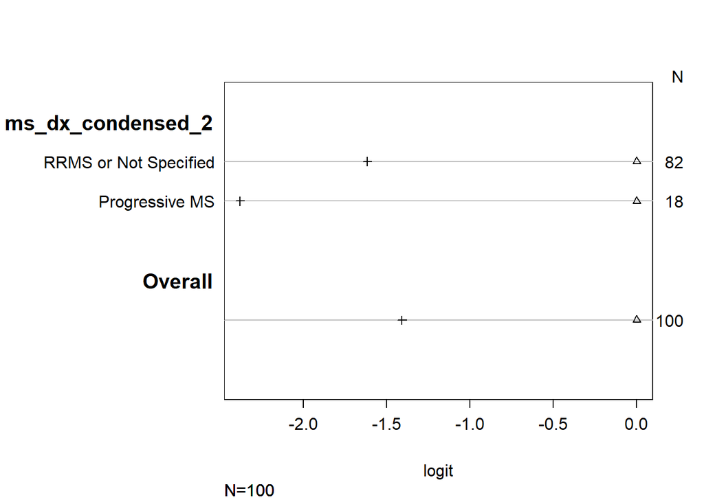

```r
# calculate the log odds of being greater than or equal to each value of the target variable
s <- with(zeno_fw_edss_df, summary(as.numeric(edss_severity_cat) ~ ms_dx_condensed_2, fun=sf))
p <- plot_check_assumption(s_var = s)
```

### Univariate - race_ethnicity_clean

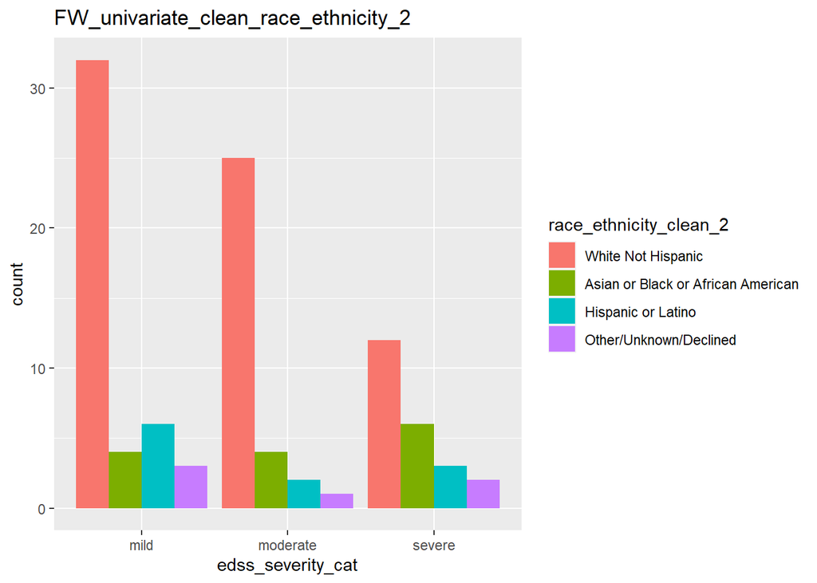

```r
filename = "FW_univariate_clean_race_ethnicity_2"

# plot
ggplot(zeno_fw_edss_df, aes(x = edss_severity_cat, fill = race_ethnicity_clean_2)) +
  geom_bar(position = "dodge") +
  labs(title = filename)
```

```r
ggsave(file.path(output_dir, paste(filename, 'vs_edss.png', sep = "_")))
# model
uni1 <- polr(edss_severity_cat ~ race_ethnicity_clean_2,
             data = zeno_fw_edss_df, Hess=TRUE)


summary_calc_p_and_odds(polr_object = uni1,
                        file_name = filename)
```

```
## Call:
## polr(formula = edss_severity_cat ~ race_ethnicity_clean_2, data = zeno_fw_edss_df,
##     Hess = TRUE)
##
## Coefficients:
##                                                             Value Std. Error
## race_ethnicity_clean_2Asian or Black or African American  0.99202     0.5559
## race_ethnicity_clean_2Hispanic or Latino                 -0.05522     0.6399
## race_ethnicity_clean_2Other/Unknown/Declined              0.21411     0.8402
##                                                           t value
## race_ethnicity_clean_2Asian or Black or African American  1.78455
## race_ethnicity_clean_2Hispanic or Latino                 -0.08629
## race_ethnicity_clean_2Other/Unknown/Declined              0.25485
##
## Intercepts:
##                 Value   Std. Error t value
## mild|moderate   -0.0731  0.2327    -0.3142
## moderate|severe  1.3764  0.2755     4.9966
##
## Residual Deviance: 209.0548
## AIC: 219.0548
## [1] "Add p-value"
##                                                                Value Std. Error
## race_ethnicity_clean_2Asian or Black or African American  0.99202476  0.5558963
## race_ethnicity_clean_2Hispanic or Latino                 -0.05521832  0.6399292
## race_ethnicity_clean_2Other/Unknown/Declined              0.21411087  0.8401596
## mild|moderate                                            -0.07312484  0.2327083
## moderate|severe                                           1.37644995  0.2754780
##                                                              t value
## race_ethnicity_clean_2Asian or Black or African American  1.78455018
## race_ethnicity_clean_2Hispanic or Latino                 -0.08628816
## race_ethnicity_clean_2Other/Unknown/Declined              0.25484547
## mild|moderate                                            -0.31423399
## moderate|severe                                           4.99658821
##                                                               p.value
## race_ethnicity_clean_2Asian or Black or African American 7.433431e-02
## race_ethnicity_clean_2Hispanic or Latino                 9.312373e-01
## race_ethnicity_clean_2Other/Unknown/Declined             7.988425e-01
## mild|moderate                                            7.533433e-01
## moderate|severe                                          5.835349e-07
```

```
## [1] -0.09235547
## [1] "Odds Ratio and CI"
##                                                                 OR  ci_2.5%
## race_ethnicity_clean_2Asian or Black or African American 2.6966891 0.911781
## race_ethnicity_clean_2Hispanic or Latino                 0.9462785 0.911781
## race_ethnicity_clean_2Other/Unknown/Declined             1.2387600 0.911781
##                                                           ci_97.5%
## race_ethnicity_clean_2Asian or Black or African American 0.2546535
## race_ethnicity_clean_2Hispanic or Latino                 0.2546535
## race_ethnicity_clean_2Other/Unknown/Declined             0.2546535
```

If significant effect: Test proportional odds assumption

```
## as.numeric(edss_severity_cat)      N= 100
##
## +----------------------+----------------------------------+---+----+----+----------+
## |                      |                                  |  N|Y>=1|Y>=2|      Y>=3|
## +----------------------+----------------------------------+---+----+----+----------+
## |race_ethnicity_clean_2|                White Not Hispanic| 69| Inf|   0|-1.7033266|
## |                      |Asian or Black or African American| 14| Inf|   0|-1.2039728|
## |                      |                Hispanic or Latino| 11| Inf|   0|-0.7985077|
## |                      |            Other/Unknown/Declined|  6| Inf|   0|-0.6931472|
## +----------------------+----------------------------------+---+----+----+----------+
## |               Overall|                                  |100| Inf|   0|-1.4089819|
## +----------------------+----------------------------------+---+----+----+----------+
```

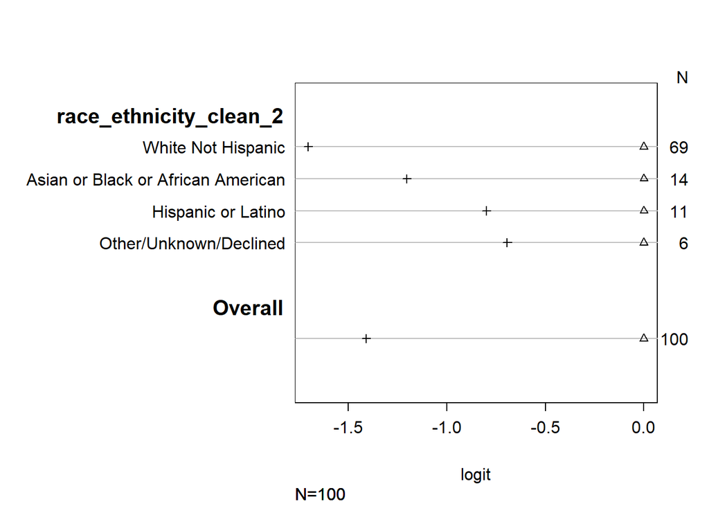

```r
# calculate the log odds of being greater than or equal to each value of the target variable
s <- with(zeno_fw_edss_df, summary(as.numeric(edss_severity_cat) ~ race_ethnicity_clean_2, fun=sf))
p <- plot_check_assumption(s_var = s)
```

### Univariate - clean_sex

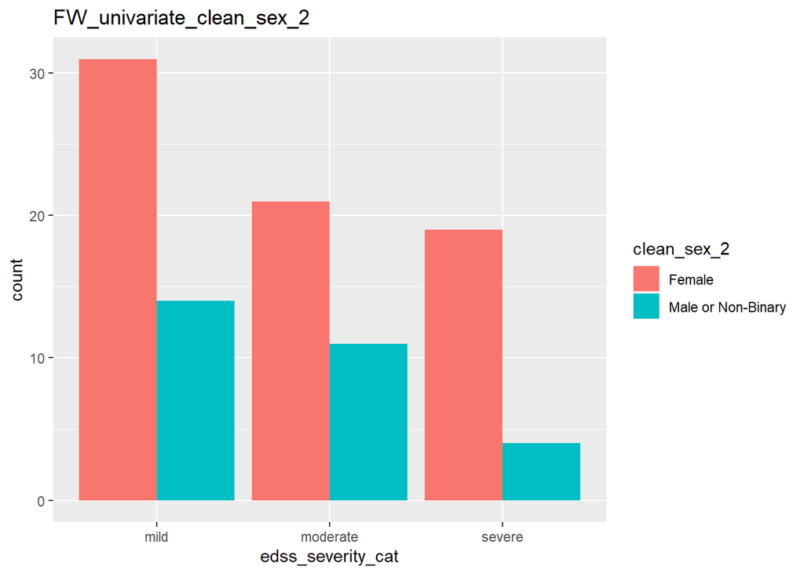

```r
filename = "FW_univariate_clean_sex_2"

# plot
ggplot(zeno_fw_edss_df, aes(x = edss_severity_cat, fill = clean_sex_2)) +
  geom_bar(position = "dodge") +
  labs(title = filename)
```

```r
ggsave(file.path(output_dir, paste(filename, 'vs_edss.png', sep = "_")))
# model
uni1 <- polr(edss_severity_cat ~ clean_sex_2,
             data = zeno_fw_edss_df, Hess=TRUE)


summary_calc_p_and_odds(polr_object = uni1,
                        file_name = filename)
```

```
## Call:
## polr(formula = edss_severity_cat ~ clean_sex_2, data = zeno_fw_edss_df,
##     Hess = TRUE)
##
## Coefficients:
##                                 Value Std. Error t value
## clean_sex_2Male or Non-Binary -0.3631     0.4091 -0.8876
##
## Intercepts:
##                 Value   Std. Error t value
## mild|moderate   -0.3135  0.2377    -1.3186
## moderate|severe  1.1042  0.2636     4.1886
##
## Residual Deviance: 211.599
## AIC: 217.599
## [1] "Add p-value"
##                                    Value Std. Error    t value      p.value
## clean_sex_2Male or Non-Binary -0.3631123  0.4090984 -0.8875916 3.747605e-01
## mild|moderate                 -0.3134636  0.2377199 -1.3186257 1.872943e-01
## moderate|severe                1.1042155  0.2636267  4.1885572 2.807336e-05
```

```
##     2.5 %
## -1.178907
## [1] "Odds Ratio and CI"
##                                      OR   ci_2.5% ci_97.5%
## clean_sex_2Male or Non-Binary 0.6955083 0.3076148 1.540126
```

If significant effect: Test proportional odds assumption

```
## as.numeric(edss_severity_cat)      N= 100
##
## +-----------+------------------+---+----+----+---------+
## |           |                  |  N|Y>=1|Y>=2|     Y>=3|
## +-----------+------------------+---+----+----+---------+
## |clean_sex_2|            Female| 71| Inf|   0|-1.261697|
## |           |Male or Non-Binary| 29| Inf|   0|-1.901574|
## +-----------+------------------+---+----+----+---------+
## |    Overall|                  |100| Inf|   0|-1.408982|
## +-----------+------------------+---+----+----+---------+
```

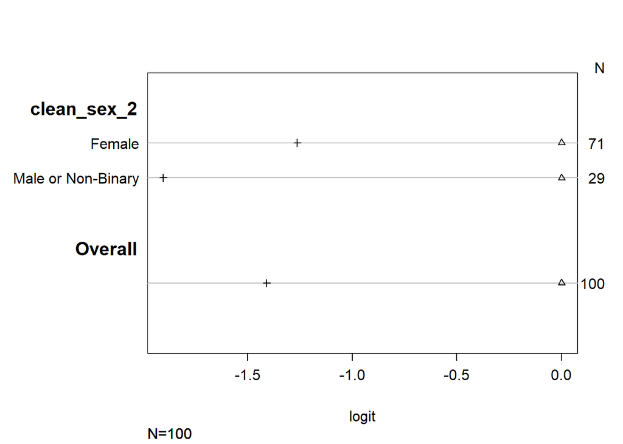

```r
# calculate the log odds of being greater than or equal to each value of the target variable
s <- with(zeno_fw_edss_df, summary(as.numeric(edss_severity_cat) ~ clean_sex_2, fun=sf))
p <- plot_check_assumption(s_var = s)
```

### Multivariate - Demographics and MS Info

```r
filename = "FW_multivar_dem_ms_info"

# model
fw_multivar_dem_ms <- polr(edss_severity_cat ~ demoEHR_Age +
                              demoEHR_DiseaseDuration +
                              ms_dx_condensed_2 +
                              race_ethnicity_clean_2 +
                              clean_sex_2,
                            data = zeno_fw_edss_df, Hess=TRUE)


summary_calc_p_and_odds(polr_object = fw_multivar_dem_ms,
                        file_name = filename)
```

```
## Call:
## polr(formula = edss_severity_cat ~ demoEHR_Age + demoEHR_DiseaseDuration +
##     ms_dx_condensed_2 + race_ethnicity_clean_2 + clean_sex_2,
##     data = zeno_fw_edss_df, Hess = TRUE)
##
## Coefficients:
##                                                             Value Std. Error
## demoEHR_Age                                               0.04992    0.02036
## demoEHR_DiseaseDuration                                   0.01421    0.02853
## ms_dx_condensed_2Progressive MS                           2.24471    0.58330
## race_ethnicity_clean_2Asian or Black or African American  1.79507    0.61694
## race_ethnicity_clean_2Hispanic or Latino                  0.39045    0.72298
## race_ethnicity_clean_2Other/Unknown/Declined              1.34722    0.93911
## clean_sex_2Male or Non-Binary                            -0.40362    0.46655
##                                                          t value
## demoEHR_Age                                               2.4524
## demoEHR_DiseaseDuration                                   0.4981
## ms_dx_condensed_2Progressive MS                           3.8483
## race_ethnicity_clean_2Asian or Black or African American  2.9096
## race_ethnicity_clean_2Hispanic or Latino                  0.5401
## race_ethnicity_clean_2Other/Unknown/Declined              1.4346
## clean_sex_2Male or Non-Binary                            -0.8651
##
## Intercepts:
##                 Value   Std. Error t value
## mild|moderate    3.0279  1.0714     2.8262
## moderate|severe  4.9688  1.1534     4.3081
##
## Residual Deviance: 175.1199
## AIC: 193.1199
## [1] "Add p-value"
##                                                                Value Std. Error
## demoEHR_Age                                               0.04992379 0.02035674
## demoEHR_DiseaseDuration                                   0.01420766 0.02852620
## ms_dx_condensed_2Progressive MS                           2.24470890 0.58329929
## race_ethnicity_clean_2Asian or Black or African American  1.79506901 0.61693782
## race_ethnicity_clean_2Hispanic or Latino                  0.39045066 0.72298236
## race_ethnicity_clean_2Other/Unknown/Declined              1.34721774 0.93910966
## clean_sex_2Male or Non-Binary                            -0.40361511 0.46655482
## mild|moderate                                             3.02790183 1.07136135
## moderate|severe                                           4.96878091 1.15335051
##                                                             t value
## demoEHR_Age                                               2.4524458
## demoEHR_DiseaseDuration                                   0.4980566
## ms_dx_condensed_2Progressive MS                           3.8482970
## race_ethnicity_clean_2Asian or Black or African American  2.9096433
## race_ethnicity_clean_2Hispanic or Latino                  0.5400556
## race_ethnicity_clean_2Other/Unknown/Declined              1.4345691
## clean_sex_2Male or Non-Binary                            -0.8650969
## mild|moderate                                             2.8262190
## moderate|severe                                           4.3081274
##                                                               p.value
## demoEHR_Age                                              1.418888e-02
## demoEHR_DiseaseDuration                                  6.184441e-01
## ms_dx_condensed_2Progressive MS                          1.189418e-04
## race_ethnicity_clean_2Asian or Black or African American 3.618415e-03
## race_ethnicity_clean_2Hispanic or Latino                 5.891587e-01
## race_ethnicity_clean_2Other/Unknown/Declined             1.514099e-01
## clean_sex_2Male or Non-Binary                            3.869856e-01
## mild|moderate                                            4.710105e-03
## moderate|severe                                          1.646426e-05
```

```
## [1] 0.01065724
## [1] "Odds Ratio and CI"
##                                                                 OR  ci_2.5%
## demoEHR_Age                                              1.0511910 1.010714
## demoEHR_DiseaseDuration                                  1.0143091 1.010714
## ms_dx_condensed_2Progressive MS                          9.4376678 1.010714
## race_ethnicity_clean_2Asian or Black or African American 6.0198901 1.010714
## race_ethnicity_clean_2Hispanic or Latino                 1.4776466 1.010714
## race_ethnicity_clean_2Other/Unknown/Declined             3.8467081 1.010714
## clean_sex_2Male or Non-Binary                            0.6679011 1.010714
##                                                           ci_97.5%
## demoEHR_Age                                              0.9592194
## demoEHR_DiseaseDuration                                  0.9592194
## ms_dx_condensed_2Progressive MS                          0.9592194
## race_ethnicity_clean_2Asian or Black or African American 0.9592194
## race_ethnicity_clean_2Hispanic or Latino                 0.9592194
## race_ethnicity_clean_2Other/Unknown/Declined             0.9592194
## clean_sex_2Male or Non-Binary                            0.9592194
```

If significant effect: Test proportional odds assumption

```
## as.numeric(edss_severity_cat)      N= 100
##
## +-----------------------+----------------------------------+---+----+----+----------+
## |                       |                                  |  N|Y>=1|Y>=2|      Y>=3|
## +-----------------------+----------------------------------+---+----+----+----------+
## |            demoEHR_Age|                           [24,41)| 26| Inf|   0|-0.4365557|
## |                       |                           [41,52)| 27| Inf|   0|-1.5557125|
## |                       |                           [52,62)| 24| Inf|   0|-2.0281482|
## |                       |                           [62,80]| 23| Inf|   0|-1.9095425|
## +-----------------------+----------------------------------+---+----+----+----------+
## |demoEHR_DiseaseDuration|                           [ 0, 5)| 30| Inf|   0|-0.9808293|
## |                       |                           [ 5, 9)| 22| Inf|   0|-1.6863990|
## |                       |                           [ 9,16)| 25| Inf|   0|-1.3499267|
## |                       |                           [16,38]| 23| Inf|   0|-1.8681324|
## +-----------------------+----------------------------------+---+----+----+----------+
## |      ms_dx_condensed_2|             RRMS or Not Specified| 82| Inf|   0|-1.6169851|
## |                       |                    Progressive MS| 18| Inf|   0|-2.3812282|
## +-----------------------+----------------------------------+---+----+----+----------+
## | race_ethnicity_clean_2|                White Not Hispanic| 69| Inf|   0|-1.7033266|
## |                       |Asian or Black or African American| 14| Inf|   0|-1.2039728|
## |                       |                Hispanic or Latino| 11| Inf|   0|-0.7985077|
## |                       |            Other/Unknown/Declined|  6| Inf|   0|-0.6931472|
## +-----------------------+----------------------------------+---+----+----+----------+
## |            clean_sex_2|                            Female| 71| Inf|   0|-1.2616970|
## |                       |                Male or Non-Binary| 29| Inf|   0|-1.9015743|
## +-----------------------+----------------------------------+---+----+----+----------+
## |                Overall|                                  |100| Inf|   0|-1.4089819|
## +-----------------------+----------------------------------+---+----+----+----------+
```

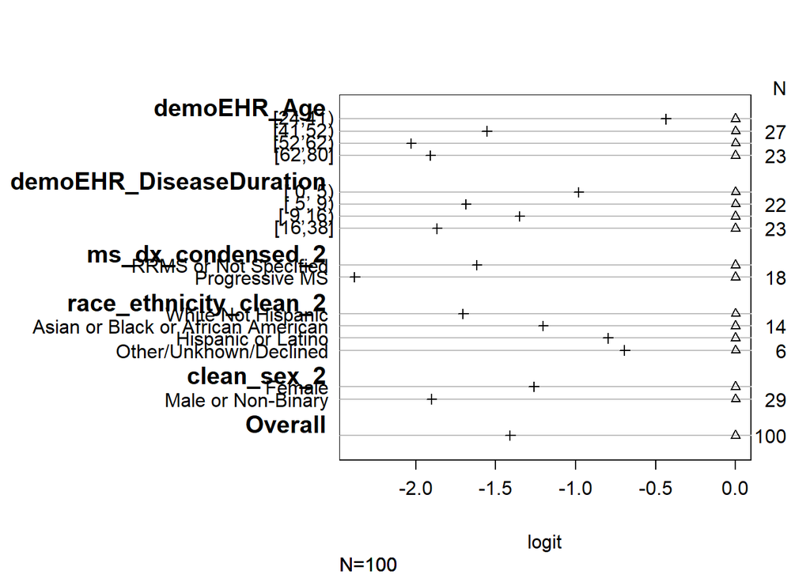

```r
# calculate the log odds of being greater than or equal to each value of the target variable
s <- with(zeno_fw_edss_df, summary(as.numeric(edss_severity_cat) ~ demoEHR_Age +
                                     demoEHR_DiseaseDuration +
                                     ms_dx_condensed_2 +
                                     race_ethnicity_clean_2 +
                                     clean_sex_2,
                                   fun=sf))
p <- plot_check_assumption(s_var = s)
```

### Multivariate - Unadj Video Metrics

```r
filename = "FW_multivar_video_unadj"

# model
fw_multivar_video_unadj <- polr(edss_severity_cat ~ log_delta_pix_h_rel_median_pose_zv +
                              stride_time_median_sec_pose_zv +
                              mean_cadence_step_per_min_pose_zv +
                              stride_width_median_cm_pose_zv,
                            data = zeno_fw_edss_df, Hess=TRUE)


summary_calc_p_and_odds(polr_object = fw_multivar_video_unadj,
                        file_name = filename)
```

```
## Call:
## polr(formula = edss_severity_cat ~ log_delta_pix_h_rel_median_pose_zv +
##     stride_time_median_sec_pose_zv + mean_cadence_step_per_min_pose_zv +
##     stride_width_median_cm_pose_zv, data = zeno_fw_edss_df, Hess = TRUE)
##
## Coefficients:
##                                        Value Std. Error t value
## log_delta_pix_h_rel_median_pose_zv -1.508491    0.60648 -2.4873
## stride_time_median_sec_pose_zv      2.831321    2.14989  1.3170
## mean_cadence_step_per_min_pose_zv  -0.005426    0.01568 -0.3461
## stride_width_median_cm_pose_zv      0.103534    0.07919  1.3075
##
## Intercepts:
##                 Value   Std. Error t value
## mild|moderate    4.4693  3.5382     1.2631
## moderate|severe  6.3250  3.5712     1.7711
##
## Residual Deviance: 178.0655
## AIC: 190.0655
## [1] "Add p-value"
##                                          Value Std. Error    t value    p.value
## log_delta_pix_h_rel_median_pose_zv -1.50849099 0.60648326 -2.4872756 0.01287256
## stride_time_median_sec_pose_zv      2.83132097 2.14988864  1.3169617 0.18785147
## mean_cadence_step_per_min_pose_zv  -0.00542585 0.01567728 -0.3460964 0.72927028
## stride_width_median_cm_pose_zv      0.10353431 0.07918703  1.3074654 0.19105470
## mild|moderate                       4.46926683 3.53823456  1.2631347 0.20654078
## moderate|severe                     6.32504864 3.57115733  1.7711481 0.07653607
```

```
## [1] -2.814541
## [1] "Odds Ratio and CI"
##                                            OR    ci_2.5%  ci_97.5%
## log_delta_pix_h_rel_median_pose_zv  0.2212436 0.05993222 0.2971938
## stride_time_median_sec_pose_zv     16.9678601 0.05993222 0.2971938
## mean_cadence_step_per_min_pose_zv   0.9945888 0.05993222 0.2971938
## stride_width_median_cm_pose_zv      1.1090838 0.05993222 0.2971938
```

If significant effect: Test proportional odds assumption - don’t think meets assumption?

```
## as.numeric(edss_severity_cat)      N= 100
##
## +----------------------------------+---------------+---+----+----+----------+
## |                                  |               |  N|Y>=1|Y>=2|      Y>=3|
## +----------------------------------+---------------+---+----+----+----------+
## |log_delta_pix_h_rel_median_pose_zv|[-3.219,-1.109)| 27| Inf|   0|-1.2584610|
## |                                  |[-1.109,-0.821)| 24| Inf|   0|-1.9459101|
## |                                  |[-0.821,-0.673)| 24| Inf|   0|-2.0614230|
## |                                  |[-0.673,-0.139]| 25| Inf|   0|-1.8669829|
## +----------------------------------+---------------+---+----+----+----------+
## |    stride_time_median_sec_pose_zv|  [0.650,0.883)| 29| Inf|   0|-0.9267620|
## |                                  |  [0.883,0.950)| 26| Inf|   0|-3.0647251|
## |                                  |  [0.950,1.033)| 20| Inf|   0|-2.0053336|
## |                                  |  [1.033,2.017]| 25| Inf|   0|-1.3062517|
## +----------------------------------+---------------+---+----+----+----------+
## | mean_cadence_step_per_min_pose_zv|    [ 56.4,110)| 25| Inf|   0|-0.8338145|
## |                                  |    [110.4,119)| 25| Inf|   0|-2.0636932|
## |                                  |    [119.0,135)| 25| Inf|   0|-2.3978953|
## |                                  |    [134.7,170]| 25| Inf|   0|-0.9044563|
## +----------------------------------+---------------+---+----+----+----------+
## |    stride_width_median_cm_pose_zv|   [ 5.72,10.5)| 25| Inf|   0|-0.7032996|
## |                                  |   [10.49,12.4)| 25| Inf|   0|-2.0724729|
## |                                  |   [12.35,13.8)| 25| Inf|   0|-1.7382708|
## |                                  |   [13.81,23.7]| 25| Inf|   0|-1.5198258|
## +----------------------------------+---------------+---+----+----+----------+
## |                           Overall|               |100| Inf|   0|-1.4089819|
## +----------------------------------+---------------+---+----+----+----------+
```

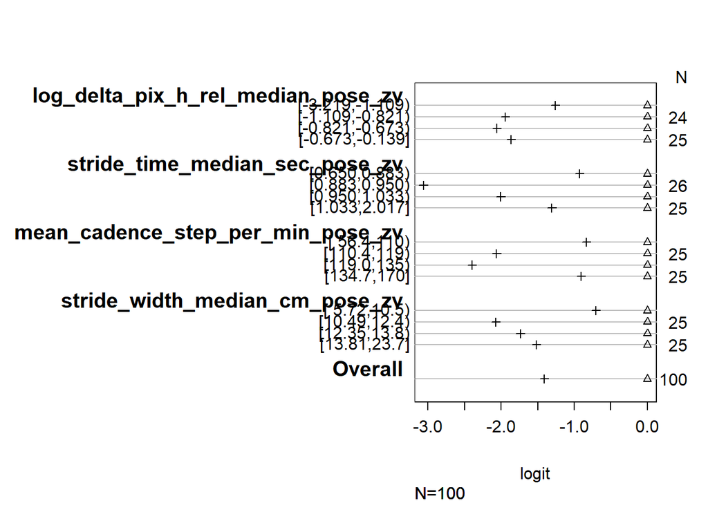

```r
# calculate the log odds of being greater than or equal to each value of the target variable
s <- with(zeno_fw_edss_df, summary(as.numeric(edss_severity_cat) ~ log_delta_pix_h_rel_median_pose_zv +
                                      stride_time_median_sec_pose_zv +
                                      mean_cadence_step_per_min_pose_zv +
                                      stride_width_median_cm_pose_zv,
                                    fun=sf))
plot_check_assumption(s)
```

### Multivariate - Adj Video Metrics

```r
filename = "FW_multivar_video_adj"

# model
fw_multivar_video_adj <- polr(edss_severity_cat ~ demoEHR_Age +
                                   demoEHR_DiseaseDuration +
                                   ms_dx_condensed_2 +
                                   race_ethnicity_clean_2 +
                                   clean_sex_2 +
                                   log_delta_pix_h_rel_median_pose_zv +
                                   stride_time_median_sec_pose_zv +
                                   mean_cadence_step_per_min_pose_zv +
                                   stride_width_median_cm_pose_zv,
                                 data = zeno_fw_edss_df, Hess=TRUE)


summary_calc_p_and_odds(polr_object = fw_multivar_video_adj,
                        file_name = filename)
```

```
## Call:
## polr(formula = edss_severity_cat ~ demoEHR_Age + demoEHR_DiseaseDuration +
##     ms_dx_condensed_2 + race_ethnicity_clean_2 + clean_sex_2 +
##     log_delta_pix_h_rel_median_pose_zv + stride_time_median_sec_pose_zv +
##     mean_cadence_step_per_min_pose_zv + stride_width_median_cm_pose_zv,
##     data = zeno_fw_edss_df, Hess = TRUE)
##
## Coefficients:
##                                                             Value Std. Error
## demoEHR_Age                                               0.04669    0.02191
## demoEHR_DiseaseDuration                                   0.01542    0.03040
## ms_dx_condensed_2Progressive MS                           1.29736    0.66968
## race_ethnicity_clean_2Asian or Black or African American  1.37312    0.66628
## race_ethnicity_clean_2Hispanic or Latino                  0.28558    0.85025
## race_ethnicity_clean_2Other/Unknown/Declined              1.54478    1.00692
## clean_sex_2Male or Non-Binary                            -0.49512    0.50065
## log_delta_pix_h_rel_median_pose_zv                       -0.96262    0.70666
## stride_time_median_sec_pose_zv                            3.13795    2.30304
## mean_cadence_step_per_min_pose_zv                        -0.00373    0.01846
## stride_width_median_cm_pose_zv                            0.09025    0.09382
##                                                          t value
## demoEHR_Age                                               2.1309
## demoEHR_DiseaseDuration                                   0.5072
## ms_dx_condensed_2Progressive MS                           1.9373
## race_ethnicity_clean_2Asian or Black or African American  2.0609
## race_ethnicity_clean_2Hispanic or Latino                  0.3359
## race_ethnicity_clean_2Other/Unknown/Declined              1.5342
## clean_sex_2Male or Non-Binary                            -0.9890
## log_delta_pix_h_rel_median_pose_zv                       -1.3622
## stride_time_median_sec_pose_zv                            1.3625
## mean_cadence_step_per_min_pose_zv                        -0.2020
## stride_width_median_cm_pose_zv                            0.9619
##
## Intercepts:
##                 Value   Std. Error t value
## mild|moderate    7.1592  4.0508     1.7674
## moderate|severe  9.3116  4.0992     2.2715
##
## Residual Deviance: 160.1039
## AIC: 186.1039
```

[output cut: 28 more lines]

```
## moderate|severe                                          4.09923612  2.2715429
##                                                             p.value
## demoEHR_Age                                              0.03309445
## demoEHR_DiseaseDuration                                  0.61201012
## ms_dx_condensed_2Progressive MS                          0.05271020
## race_ethnicity_clean_2Asian or Black or African American 0.03931429
## race_ethnicity_clean_2Hispanic or Latino                 0.73696138
## race_ethnicity_clean_2Other/Unknown/Declined             0.12499089
## clean_sex_2Male or Non-Binary                            0.32268455
## log_delta_pix_h_rel_median_pose_zv                       0.17313202
## stride_time_median_sec_pose_zv                           0.17303169
## mean_cadence_step_per_min_pose_zv                        0.83989757
## stride_width_median_cm_pose_zv                           0.33607510
## mild|moderate                                            0.07716905
## moderate|severe                                          0.02311413
```

```
## [1] 0.00420344
## [1] "Odds Ratio and CI"
##                                                                  OR  ci_2.5%
## demoEHR_Age                                               1.0478013 1.004212
## demoEHR_DiseaseDuration                                   1.0155400 1.004212
## ms_dx_condensed_2Progressive MS                           3.6596388 1.004212
## race_ethnicity_clean_2Asian or Black or African American  3.9476360 1.004212
## race_ethnicity_clean_2Hispanic or Latino                  1.3305340 1.004212
## race_ethnicity_clean_2Other/Unknown/Declined              4.6869477 1.004212
## clean_sex_2Male or Non-Binary                             0.6094968 1.004212
## log_delta_pix_h_rel_median_pose_zv                        0.3818927 1.004212
## stride_time_median_sec_pose_zv                           23.0565276 1.004212
## mean_cadence_step_per_min_pose_zv                         0.9962769 1.004212
## stride_width_median_cm_pose_zv                            1.0944499 1.004212
##                                                           ci_97.5%
## demoEHR_Age                                              0.9567827
## demoEHR_DiseaseDuration                                  0.9567827
## ms_dx_condensed_2Progressive MS                          0.9567827
## race_ethnicity_clean_2Asian or Black or African American 0.9567827
## race_ethnicity_clean_2Hispanic or Latino                 0.9567827
## race_ethnicity_clean_2Other/Unknown/Declined             0.9567827
## clean_sex_2Male or Non-Binary                            0.9567827
## log_delta_pix_h_rel_median_pose_zv                       0.9567827
## stride_time_median_sec_pose_zv                           0.9567827
## mean_cadence_step_per_min_pose_zv                        0.9567827
## stride_width_median_cm_pose_zv                           0.9567827
```

### Plot multivariate models

Each video metric that was sig in univariate model with race and dx Race, MS DX, and Log Pixel Proxy

```r
filename = "FW_multivar_logPix_dx_race"

# model
FW_multivar_logPixdx_race <- polr(edss_severity_cat ~ log_delta_pix_h_rel_median_pose_zv +
                              ms_dx_condensed_2 +
                              race_ethnicity_clean_2,
                            data = zeno_fw_edss_df, Hess=TRUE)


summary_calc_p_and_odds(polr_object = FW_multivar_logPixdx_race,
                        file_name = filename)
```

```
## Call:
## polr(formula = edss_severity_cat ~ log_delta_pix_h_rel_median_pose_zv +
##     ms_dx_condensed_2 + race_ethnicity_clean_2, data = zeno_fw_edss_df,
##     Hess = TRUE)
##
## Coefficients:
##                                                            Value Std. Error
## log_delta_pix_h_rel_median_pose_zv                       -1.9910     0.5640
## ms_dx_condensed_2Progressive MS                           1.7474     0.6217
## race_ethnicity_clean_2Asian or Black or African American  1.0724     0.6192
## race_ethnicity_clean_2Hispanic or Latino                 -0.6691     0.7367
## race_ethnicity_clean_2Other/Unknown/Declined              0.9340     0.8937
##                                                          t value
## log_delta_pix_h_rel_median_pose_zv                       -3.5301
## ms_dx_condensed_2Progressive MS                           2.8106
## race_ethnicity_clean_2Asian or Black or African American  1.7320
## race_ethnicity_clean_2Hispanic or Latino                 -0.9082
## race_ethnicity_clean_2Other/Unknown/Declined              1.0451
##
## Intercepts:
##                 Value   Std. Error t value
## mild|moderate    1.9509  0.5386     3.6219
## moderate|severe  3.9404  0.6572     5.9958
##
## Residual Deviance: 170.498
## AIC: 184.498
## [1] "Add p-value"
##                                                               Value Std. Error
## log_delta_pix_h_rel_median_pose_zv                       -1.9909862  0.5640040
## ms_dx_condensed_2Progressive MS                           1.7473554  0.6216994
## race_ethnicity_clean_2Asian or Black or African American  1.0723605  0.6191513
## race_ethnicity_clean_2Hispanic or Latino                 -0.6691443  0.7367442
## race_ethnicity_clean_2Other/Unknown/Declined              0.9339844  0.8936558
## mild|moderate                                             1.9509256  0.5386409
## moderate|severe                                           3.9403916  0.6571929
##                                                             t value
## log_delta_pix_h_rel_median_pose_zv                       -3.5300926
## ms_dx_condensed_2Progressive MS                           2.8106113
## race_ethnicity_clean_2Asian or Black or African American  1.7319844
## race_ethnicity_clean_2Hispanic or Latino                 -0.9082451
## race_ethnicity_clean_2Other/Unknown/Declined              1.0451276
## mild|moderate                                             3.6219410
## moderate|severe                                           5.9957912
##                                                               p.value
## log_delta_pix_h_rel_median_pose_zv                       4.154143e-04
## ms_dx_condensed_2Progressive MS                          4.944749e-03
## race_ethnicity_clean_2Asian or Black or African American 8.327633e-02
## race_ethnicity_clean_2Hispanic or Latino                 3.637487e-01
## race_ethnicity_clean_2Other/Unknown/Declined             2.959640e-01
## mild|moderate                                            2.924009e-04
## moderate|severe                                          2.024971e-09
```

```
## [1] -3.15944
## [1] "Odds Ratio and CI"
##                                                                 OR   ci_2.5%
## log_delta_pix_h_rel_median_pose_zv                       0.1365607 0.0424495
## ms_dx_condensed_2Progressive MS                          5.7394040 0.0424495
## race_ethnicity_clean_2Asian or Black or African American 2.9222693 0.0424495
## race_ethnicity_clean_2Hispanic or Latino                 0.5121466 0.0424495
## race_ethnicity_clean_2Other/Unknown/Declined             2.5446278 0.0424495
##                                                          ci_97.5%
## log_delta_pix_h_rel_median_pose_zv                         1.7342
## ms_dx_condensed_2Progressive MS                            1.7342
## race_ethnicity_clean_2Asian or Black or African American   1.7342
## race_ethnicity_clean_2Hispanic or Latino                   1.7342
## race_ethnicity_clean_2Other/Unknown/Declined               1.7342
```

```
## as.numeric(edss_severity_cat)      N= 100
##
## +----------------------------------+----------------------------------+---+----+----+----------+
## |                                  |                                  |  N|Y>=1|Y>=2|      Y>=3|
## +----------------------------------+----------------------------------+---+----+----+----------+
## |log_delta_pix_h_rel_median_pose_zv|                   [-3.219,-1.109)| 27| Inf|   0|-1.2584610|
## |                                  |                   [-1.109,-0.821)| 24| Inf|   0|-1.9459101|
## |                                  |                   [-0.821,-0.673)| 24| Inf|   0|-2.0614230|
## |                                  |                   [-0.673,-0.139]| 25| Inf|   0|-1.8669829|
## +----------------------------------+----------------------------------+---+----+----+----------+
## |                 ms_dx_condensed_2|             RRMS or Not Specified| 82| Inf|   0|-1.6169851|
## |                                  |                    Progressive MS| 18| Inf|   0|-2.3812282|
## +----------------------------------+----------------------------------+---+----+----+----------+
## |            race_ethnicity_clean_2|                White Not Hispanic| 69| Inf|   0|-1.7033266|
## |                                  |Asian or Black or African American| 14| Inf|   0|-1.2039728|
## |                                  |                Hispanic or Latino| 11| Inf|   0|-0.7985077|
## |                                  |            Other/Unknown/Declined|  6| Inf|   0|-0.6931472|
## +----------------------------------+----------------------------------+---+----+----+----------+
## |                           Overall|                                  |100| Inf|   0|-1.4089819|
## +----------------------------------+----------------------------------+---+----+----+----------+
```

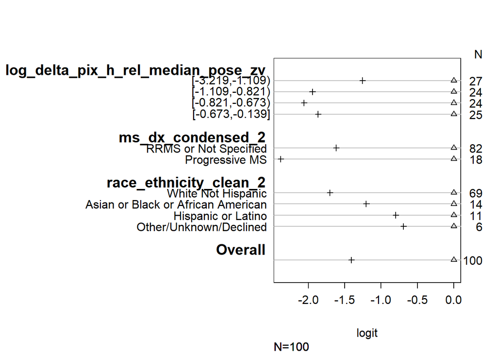

```r
# calculate the log odds of being greater than or equal to each value of the target variable
s <- with(zeno_fw_edss_df, summary(as.numeric(edss_severity_cat) ~ log_delta_pix_h_rel_median_pose_zv +
                                      ms_dx_condensed_2 +
                                      race_ethnicity_clean_2,
                                    fun=sf))
plot_check_assumption(s)
```

```r
# save original levels to create df
ms_dx_levels <- levels(FW_multivar_logPixdx_race$model$ms_dx_condensed_2)
ms_dx_levels
```

```
## [1] "RRMS or Not Specified" "Progressive MS"
```

```r
race_levels <- levels(FW_multivar_logPixdx_race$model$race_ethnicity_clean_2)
race_levels
```

```
## [1] "White Not Hispanic"                 "Asian or Black or African American"
## [3] "Hispanic or Latino"                 "Other/Unknown/Declined"
```

```r
# Define continuous variable ranges
log_pix_values <- seq(from = -3.219, to = -0.139, length.out = 100)

# Generate all combinations of categorical variables
cat_combinations <- expand.grid(
  ms_dx_condensed_2 = ms_dx_levels,
  race_ethnicity_clean_2 = race_levels,
  stringsAsFactors = TRUE  # Ensures they are factors
)

head(cat_combinations)
```

```
##       ms_dx_condensed_2             race_ethnicity_clean_2
## 1 RRMS or Not Specified                 White Not Hispanic
## 2        Progressive MS                 White Not Hispanic
## 3 RRMS or Not Specified Asian or Black or African American
## 4        Progressive MS Asian or Black or African American
## 5 RRMS or Not Specified                 Hispanic or Latino
## 6        Progressive MS                 Hispanic or Latino
```

```r
# Expand dataset to include all continuous variable values for each categorical combination
newdat <- expand.grid(
  log_delta_pix_h_rel_median_pose_zv = log_pix_values,
  stringsAsFactors = FALSE  # Keep continuous variables numeric
)

# Use `merge()` to properly combine categorical and continuous variables
newdat <- merge(cat_combinations, newdat, by = NULL)

# predict for each row of new dat using model
newdat <- cbind(newdat, predict(FW_multivar_logPixdx_race, newdat, type = "probs"))
head(newdat)
```

```
##       ms_dx_condensed_2             race_ethnicity_clean_2
## 1 RRMS or Not Specified                 White Not Hispanic
## 2        Progressive MS                 White Not Hispanic
## 3 RRMS or Not Specified Asian or Black or African American
## 4        Progressive MS Asian or Black or African American
## 5 RRMS or Not Specified                 Hispanic or Latino
## 6        Progressive MS                 Hispanic or Latino
##   log_delta_pix_h_rel_median_pose_zv        mild    moderate    severe
## 1                             -3.219 0.011452156 0.066637305 0.9219105
## 2                             -3.219 0.002014406 0.012529271 0.9854563
## 3                             -3.219 0.003948672 0.024220500 0.9718308
## 4                             -3.219 0.000690244 0.004334672 0.9949751
## 5                             -3.219 0.022119785 0.119798392 0.8580818
## 6                             -3.219 0.003925728 0.024083721 0.9719906
```

```r
head(newdat)
```

```
##       ms_dx_condensed_2             race_ethnicity_clean_2
## 1 RRMS or Not Specified                 White Not Hispanic
## 2        Progressive MS                 White Not Hispanic
## 3 RRMS or Not Specified Asian or Black or African American
## 4        Progressive MS Asian or Black or African American
## 5 RRMS or Not Specified                 Hispanic or Latino
## 6        Progressive MS                 Hispanic or Latino
##   log_delta_pix_h_rel_median_pose_zv        mild    moderate    severe
## 1                             -3.219 0.011452156 0.066637305 0.9219105
## 2                             -3.219 0.002014406 0.012529271 0.9854563
## 3                             -3.219 0.003948672 0.024220500 0.9718308
## 4                             -3.219 0.000690244 0.004334672 0.9949751
## 5                             -3.219 0.022119785 0.119798392 0.8580818
## 6                             -3.219 0.003925728 0.024083721 0.9719906
```

```r
# reshape for plotting
lnewdat <- melt(newdat, id.vars = c("log_delta_pix_h_rel_median_pose_zv",
                                    "ms_dx_condensed_2",
                                    "race_ethnicity_clean_2"),
                variable.name = "Level", value.name="Probability")
head(lnewdat)
```

```
##   log_delta_pix_h_rel_median_pose_zv     ms_dx_condensed_2
## 1                             -3.219 RRMS or Not Specified
## 2                             -3.219        Progressive MS
## 3                             -3.219 RRMS or Not Specified
## 4                             -3.219        Progressive MS
## 5                             -3.219 RRMS or Not Specified
## 6                             -3.219        Progressive MS
##               race_ethnicity_clean_2 Level Probability
## 1                 White Not Hispanic  mild 0.011452156
## 2                 White Not Hispanic  mild 0.002014406
## 3 Asian or Black or African American  mild 0.003948672
## 4 Asian or Black or African American  mild 0.000690244
## 5                 Hispanic or Latino  mild 0.022119785
## 6                 Hispanic or Latino  mild 0.003925728
```

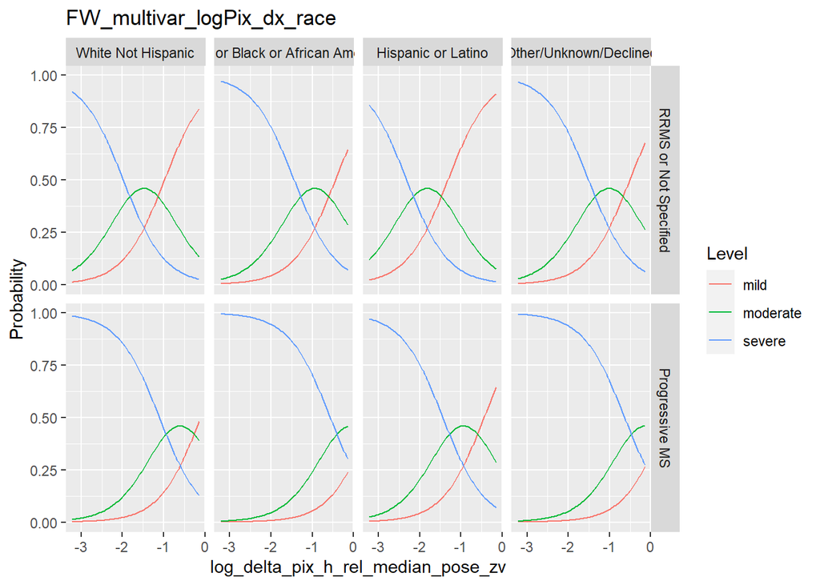

```r
# plot all of the predicted probabilities for the different conditions.
# example
#ggplot(lnewdat, aes(x = gpa, y = Probability, colour = Level)) +
  #geom_line() + facet_grid(pared ~ public, labeller="label_both")

p <- ggplot(lnewdat, aes(x = log_delta_pix_h_rel_median_pose_zv, y = Probability, colour = Level)) +
  geom_line() +
  facet_grid(ms_dx_condensed_2 ~ race_ethnicity_clean_2) +
  labs(title = filename)
p
```

```r
ggsave(file.path(output_dir, paste(filename, "probabilities.png", sep = "_")))
```

Race, MS DX, and Stride Time

```r
filename = "FW_multivar_strideTime_dx_race"

# model
FW_multivar_strideTime_dx_race <- polr(edss_severity_cat ~ stride_time_median_sec_pose_zv +
                              ms_dx_condensed_2 +
                              race_ethnicity_clean_2,
                            data = zeno_fw_edss_df, Hess=TRUE)


summary_calc_p_and_odds(polr_object = FW_multivar_strideTime_dx_race,
                        file_name = filename)
```

```
## Call:
## polr(formula = edss_severity_cat ~ stride_time_median_sec_pose_zv +
##     ms_dx_condensed_2 + race_ethnicity_clean_2, data = zeno_fw_edss_df,
##     Hess = TRUE)
##
## Coefficients:
##                                                             Value Std. Error
## stride_time_median_sec_pose_zv                            4.28429     1.6676
## ms_dx_condensed_2Progressive MS                           1.95251     0.5986
## race_ethnicity_clean_2Asian or Black or African American  1.21369     0.6163
## race_ethnicity_clean_2Hispanic or Latino                 -0.05235     0.6676
## race_ethnicity_clean_2Other/Unknown/Declined              0.72465     0.9174
##                                                           t value
## stride_time_median_sec_pose_zv                            2.56920
## ms_dx_condensed_2Progressive MS                           3.26194
## race_ethnicity_clean_2Asian or Black or African American  1.96945
## race_ethnicity_clean_2Hispanic or Latino                 -0.07841
## race_ethnicity_clean_2Other/Unknown/Declined              0.78992
##
## Intercepts:
##                 Value   Std. Error t value
## mild|moderate    4.3070  1.5768     2.7315
## moderate|severe  6.1869  1.6421     3.7676
##
## Residual Deviance: 177.4336
## AIC: 191.4336
## [1] "Add p-value"
##                                                                Value Std. Error
## stride_time_median_sec_pose_zv                            4.28428660  1.6675584
## ms_dx_condensed_2Progressive MS                           1.95250886  0.5985733
## race_ethnicity_clean_2Asian or Black or African American  1.21369026  0.6162584
## race_ethnicity_clean_2Hispanic or Latino                 -0.05234731  0.6675790
## race_ethnicity_clean_2Other/Unknown/Declined              0.72465409  0.9173806
## mild|moderate                                             4.30695505  1.5767906
## moderate|severe                                           6.18688471  1.6421268
##                                                              t value
## stride_time_median_sec_pose_zv                            2.56919739
## ms_dx_condensed_2Progressive MS                           3.26193791
## race_ethnicity_clean_2Asian or Black or African American  1.96945012
## race_ethnicity_clean_2Hispanic or Latino                 -0.07841366
## race_ethnicity_clean_2Other/Unknown/Declined              0.78991656
## mild|moderate                                             2.73146924
## moderate|severe                                           3.76760471
##                                                               p.value
## stride_time_median_sec_pose_zv                           0.0101934376
## ms_dx_condensed_2Progressive MS                          0.0011065338
## race_ethnicity_clean_2Asian or Black or African American 0.0489014251
## race_ethnicity_clean_2Hispanic or Latino                 0.9374990056
## race_ethnicity_clean_2Other/Unknown/Declined             0.4295764981
## mild|moderate                                            0.0063052626
## moderate|severe                                          0.0001648214
```

```
## [1] 1.206788
## [1] "Odds Ratio and CI"
##                                                                  OR ci_2.5%
## stride_time_median_sec_pose_zv                           72.5507702 3.34273
## ms_dx_condensed_2Progressive MS                           7.0463437 3.34273
## race_ethnicity_clean_2Asian or Black or African American  3.3658828 3.34273
## race_ethnicity_clean_2Hispanic or Latino                  0.9489992 3.34273
## race_ethnicity_clean_2Other/Unknown/Declined              2.0640170 3.34273
##                                                          ci_97.5%
## stride_time_median_sec_pose_zv                           2.252083
## ms_dx_condensed_2Progressive MS                          2.252083
## race_ethnicity_clean_2Asian or Black or African American 2.252083
## race_ethnicity_clean_2Hispanic or Latino                 2.252083
## race_ethnicity_clean_2Other/Unknown/Declined             2.252083
```

```
## as.numeric(edss_severity_cat)      N= 100
##
## +------------------------------+----------------------------------+---+----+----+----------+
## |                              |                                  |  N|Y>=1|Y>=2|      Y>=3|
## +------------------------------+----------------------------------+---+----+----+----------+
## |stride_time_median_sec_pose_zv|                     [0.650,0.883)| 29| Inf|   0|-0.9267620|
## |                              |                     [0.883,0.950)| 26| Inf|   0|-3.0647251|
## |                              |                     [0.950,1.033)| 20| Inf|   0|-2.0053336|
## |                              |                     [1.033,2.017]| 25| Inf|   0|-1.3062517|
## +------------------------------+----------------------------------+---+----+----+----------+
## |             ms_dx_condensed_2|             RRMS or Not Specified| 82| Inf|   0|-1.6169851|
## |                              |                    Progressive MS| 18| Inf|   0|-2.3812282|
## +------------------------------+----------------------------------+---+----+----+----------+
## |        race_ethnicity_clean_2|                White Not Hispanic| 69| Inf|   0|-1.7033266|
## |                              |Asian or Black or African American| 14| Inf|   0|-1.2039728|
## |                              |                Hispanic or Latino| 11| Inf|   0|-0.7985077|
## |                              |            Other/Unknown/Declined|  6| Inf|   0|-0.6931472|
## +------------------------------+----------------------------------+---+----+----+----------+
## |                       Overall|                                  |100| Inf|   0|-1.4089819|
## +------------------------------+----------------------------------+---+----+----+----------+
```

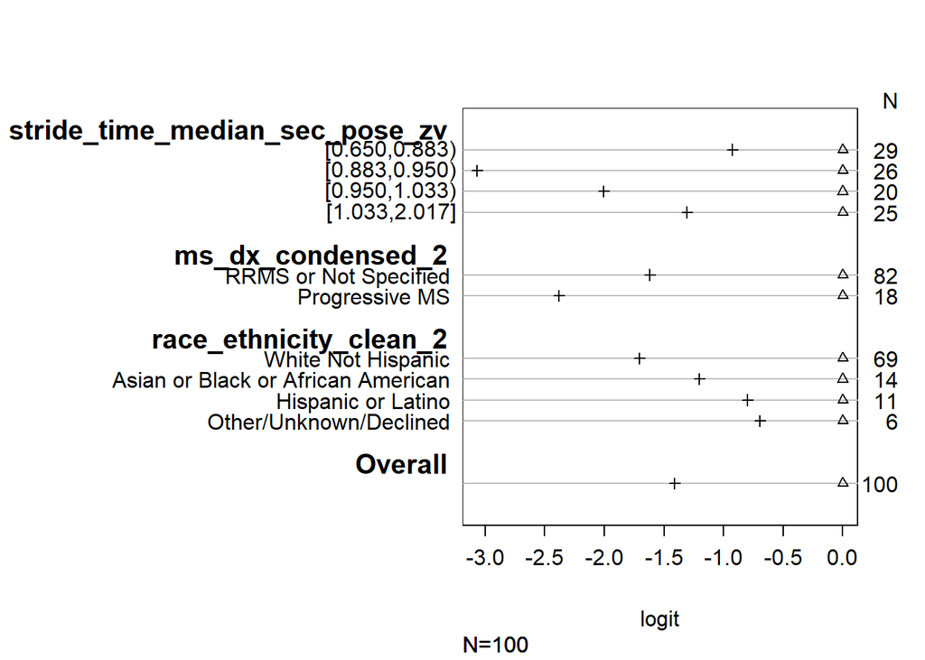

```r
# calculate the log odds of being greater than or equal to each value of the target variable
s <- with(zeno_fw_edss_df, summary(as.numeric(edss_severity_cat) ~ stride_time_median_sec_pose_zv +
                                      ms_dx_condensed_2 +
                                      race_ethnicity_clean_2,
                                    fun=sf))
plot_check_assumption(s)
```

```r
# save original levels to create df
ms_dx_levels <- levels(FW_multivar_strideTime_dx_race$model$ms_dx_condensed_2)
ms_dx_levels
```

```
## [1] "RRMS or Not Specified" "Progressive MS"
```

```r
race_levels <- levels(FW_multivar_logPixdx_race$model$race_ethnicity_clean_2)
race_levels
```

```
## [1] "White Not Hispanic"                 "Asian or Black or African American"
## [3] "Hispanic or Latino"                 "Other/Unknown/Declined"
```

```r
# Define continuous variable ranges
stride_time_values <- seq(from = 0.650, to = 2.017, length.out = 100)

# Generate all combinations of categorical variables
cat_combinations <- expand.grid(
  ms_dx_condensed_2 = ms_dx_levels,
  race_ethnicity_clean_2 = race_levels,
  stringsAsFactors = TRUE  # Ensures they are factors
)

head(cat_combinations)
```

```
##       ms_dx_condensed_2             race_ethnicity_clean_2
## 1 RRMS or Not Specified                 White Not Hispanic
## 2        Progressive MS                 White Not Hispanic
## 3 RRMS or Not Specified Asian or Black or African American
## 4        Progressive MS Asian or Black or African American
## 5 RRMS or Not Specified                 Hispanic or Latino
## 6        Progressive MS                 Hispanic or Latino
```

```r
# Expand dataset to include all continuous variable values for each categorical combination
newdat <- expand.grid(
  stride_time_median_sec_pose_zv = stride_time_values,
  stringsAsFactors = FALSE  # Keep continuous variables numeric
)

# Use `merge()` to properly combine categorical and continuous variables
newdat <- merge(cat_combinations, newdat, by = NULL)

# predict for each row of new dat using model
newdat <- cbind(newdat, predict(FW_multivar_strideTime_dx_race, newdat, type = "probs"))
head(newdat)
```

```
##       ms_dx_condensed_2             race_ethnicity_clean_2
## 1 RRMS or Not Specified                 White Not Hispanic
## 2        Progressive MS                 White Not Hispanic
## 3 RRMS or Not Specified Asian or Black or African American
## 4        Progressive MS Asian or Black or African American
## 5 RRMS or Not Specified                 Hispanic or Latino
## 6        Progressive MS                 Hispanic or Latino
##   stride_time_median_sec_pose_zv      mild  moderate     severe
## 1                           0.65 0.8208576 0.1469124 0.03222995
## 2                           0.65 0.3940451 0.4158901 0.19006474
## 3                           0.65 0.5765138 0.3226899 0.10079628
## 4                           0.65 0.1619174 0.3967855 0.44129715
## 5                           0.65 0.8284265 0.1409370 0.03063655
## 6                           0.65 0.4066111 0.4112521 0.18213682
```

```r
# reshape for plotting
lnewdat <- melt(newdat, id.vars = c("stride_time_median_sec_pose_zv",
                                    "ms_dx_condensed_2",
                                    "race_ethnicity_clean_2"),
                variable.name = "Level", value.name="Probability")
head(lnewdat)
```

```
##   stride_time_median_sec_pose_zv     ms_dx_condensed_2
## 1                           0.65 RRMS or Not Specified
## 2                           0.65        Progressive MS
## 3                           0.65 RRMS or Not Specified
## 4                           0.65        Progressive MS
## 5                           0.65 RRMS or Not Specified
## 6                           0.65        Progressive MS
##               race_ethnicity_clean_2 Level Probability
## 1                 White Not Hispanic  mild   0.8208576
## 2                 White Not Hispanic  mild   0.3940451
## 3 Asian or Black or African American  mild   0.5765138
## 4 Asian or Black or African American  mild   0.1619174
## 5                 Hispanic or Latino  mild   0.8284265
## 6                 Hispanic or Latino  mild   0.4066111
```

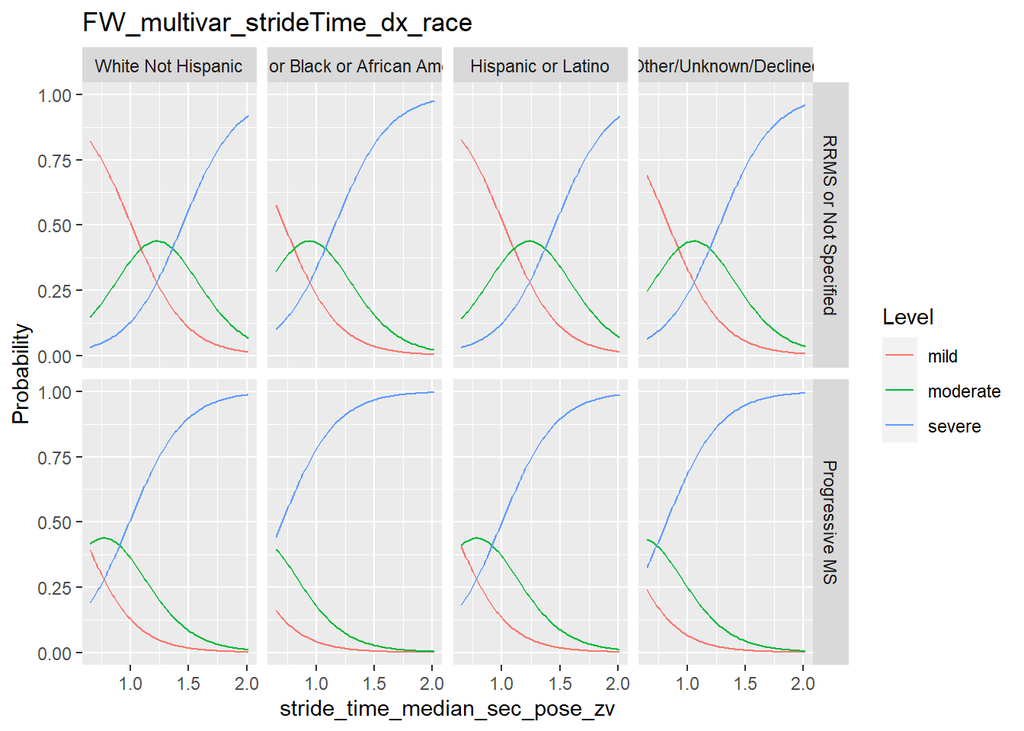

```r
# plot all of the predicted probabilities for the different conditions.
# example
#ggplot(lnewdat, aes(x = gpa, y = Probability, colour = Level)) +
  #geom_line() + facet_grid(pared ~ public, labeller="label_both")

p <- ggplot(lnewdat, aes(x = stride_time_median_sec_pose_zv, y = Probability, colour = Level)) +
  geom_line() +
  facet_grid(ms_dx_condensed_2 ~ race_ethnicity_clean_2) +
  labs(title = filename)
p
```

```r
ggsave(file.path(output_dir, paste(filename, "probabilities.png", sep = "_")))
```

Race, MS DX, and Cadence

```r
filename = "FW_multivar_cadence_dx_race"

# model
FW_multivar_cadence_dx_race <- polr(edss_severity_cat ~ mean_cadence_step_per_min_pose_zv +
                              ms_dx_condensed_2 +
                              race_ethnicity_clean_2,
                            data = zeno_fw_edss_df, Hess=TRUE)


summary_calc_p_and_odds(polr_object = FW_multivar_cadence_dx_race,
                        file_name = filename)
```

```
## Call:
## polr(formula = edss_severity_cat ~ mean_cadence_step_per_min_pose_zv +
##     ms_dx_condensed_2 + race_ethnicity_clean_2, data = zeno_fw_edss_df,
##     Hess = TRUE)
##
## Coefficients:
##                                                             Value Std. Error
## mean_cadence_step_per_min_pose_zv                        -0.02373    0.01233
## ms_dx_condensed_2Progressive MS                           2.07928    0.60857
## race_ethnicity_clean_2Asian or Black or African American  1.29876    0.59973
## race_ethnicity_clean_2Hispanic or Latino                  0.08336    0.69027
## race_ethnicity_clean_2Other/Unknown/Declined              0.74810    0.87761
##                                                          t value
## mean_cadence_step_per_min_pose_zv                        -1.9252
## ms_dx_condensed_2Progressive MS                           3.4167
## race_ethnicity_clean_2Asian or Black or African American  2.1656
## race_ethnicity_clean_2Hispanic or Latino                  0.1208
## race_ethnicity_clean_2Other/Unknown/Declined              0.8524
##
## Intercepts:
##                 Value   Std. Error t value
## mild|moderate   -2.5710  1.5249    -1.6860
## moderate|severe -0.7351  1.5165    -0.4848
##
## Residual Deviance: 181.4143
## AIC: 195.4143
## [1] "Add p-value"
##                                                                Value Std. Error
## mean_cadence_step_per_min_pose_zv                        -0.02372941 0.01232565
## ms_dx_condensed_2Progressive MS                           2.07928370 0.60857109
## race_ethnicity_clean_2Asian or Black or African American  1.29876181 0.59973125
## race_ethnicity_clean_2Hispanic or Latino                  0.08336441 0.69027128
## race_ethnicity_clean_2Other/Unknown/Declined              0.74809925 0.87760818
## mild|moderate                                            -2.57104969 1.52493170
## moderate|severe                                          -0.73513339 1.51648056
##                                                             t value
## mean_cadence_step_per_min_pose_zv                        -1.9252048
## ms_dx_condensed_2Progressive MS                           3.4166653
## race_ethnicity_clean_2Asian or Black or African American  2.1655730
## race_ethnicity_clean_2Hispanic or Latino                  0.1207705
## race_ethnicity_clean_2Other/Unknown/Declined              0.8524297
## mild|moderate                                            -1.6860097
## moderate|severe                                          -0.4847628
##                                                               p.value
## mean_cadence_step_per_min_pose_zv                        0.0542037410
## ms_dx_condensed_2Progressive MS                          0.0006339317
## race_ethnicity_clean_2Asian or Black or African American 0.0303438298
## race_ethnicity_clean_2Hispanic or Latino                 0.9038728082
## race_ethnicity_clean_2Other/Unknown/Declined             0.3939756603
## mild|moderate                                            0.0917939237
## moderate|severe                                          0.6278445999
```

```
## [1] -0.04884963
## [1] "Odds Ratio and CI"
##                                                                 OR   ci_2.5%
## mean_cadence_step_per_min_pose_zv                        0.9765499 0.9523243
## ms_dx_condensed_2Progressive MS                          7.9987373 0.9523243
## race_ethnicity_clean_2Asian or Black or African American 3.6647562 0.9523243
## race_ethnicity_clean_2Hispanic or Latino                 1.0869378 0.9523243
## race_ethnicity_clean_2Other/Unknown/Declined             2.1129799 0.9523243
##                                                          ci_97.5%
## mean_cadence_step_per_min_pose_zv                        2.510736
## ms_dx_condensed_2Progressive MS                          2.510736
## race_ethnicity_clean_2Asian or Black or African American 2.510736
## race_ethnicity_clean_2Hispanic or Latino                 2.510736
## race_ethnicity_clean_2Other/Unknown/Declined             2.510736
```

```
## as.numeric(edss_severity_cat)      N= 100
##
## +---------------------------------+----------------------------------+---+----+----+----------+
## |                                 |                                  |  N|Y>=1|Y>=2|      Y>=3|
## +---------------------------------+----------------------------------+---+----+----+----------+
## |mean_cadence_step_per_min_pose_zv|                       [ 56.4,110)| 25| Inf|   0|-0.8338145|
## |                                 |                       [110.4,119)| 25| Inf|   0|-2.0636932|
## |                                 |                       [119.0,135)| 25| Inf|   0|-2.3978953|
## |                                 |                       [134.7,170]| 25| Inf|   0|-0.9044563|
## +---------------------------------+----------------------------------+---+----+----+----------+
## |                ms_dx_condensed_2|             RRMS or Not Specified| 82| Inf|   0|-1.6169851|
## |                                 |                    Progressive MS| 18| Inf|   0|-2.3812282|
## +---------------------------------+----------------------------------+---+----+----+----------+
## |           race_ethnicity_clean_2|                White Not Hispanic| 69| Inf|   0|-1.7033266|
## |                                 |Asian or Black or African American| 14| Inf|   0|-1.2039728|
## |                                 |                Hispanic or Latino| 11| Inf|   0|-0.7985077|
## |                                 |            Other/Unknown/Declined|  6| Inf|   0|-0.6931472|
## +---------------------------------+----------------------------------+---+----+----+----------+
## |                          Overall|                                  |100| Inf|   0|-1.4089819|
## +---------------------------------+----------------------------------+---+----+----+----------+
```

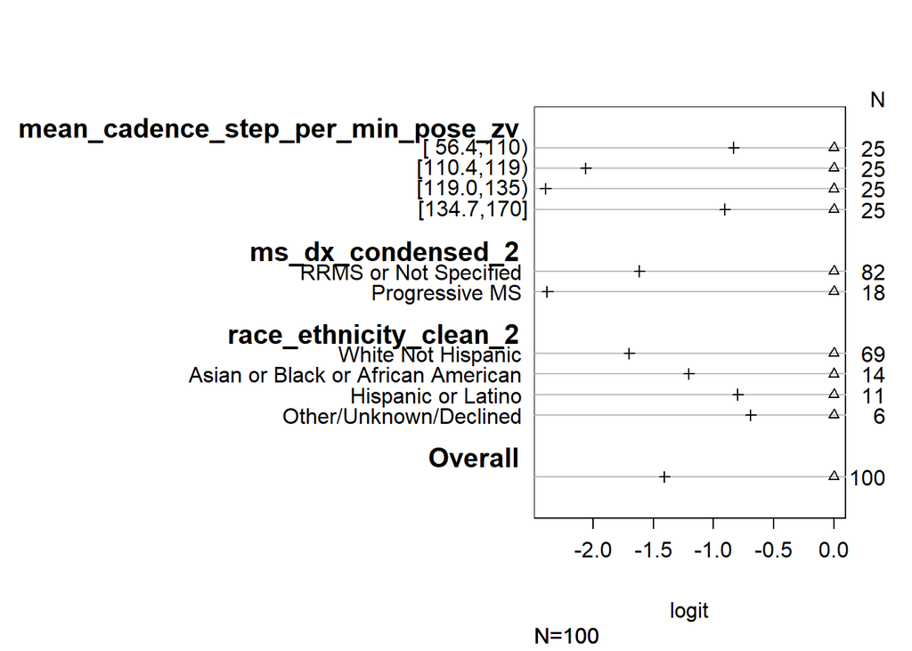

```r
# calculate the log odds of being greater than or equal to each value of the target variable
s <- with(zeno_fw_edss_df, summary(as.numeric(edss_severity_cat) ~ mean_cadence_step_per_min_pose_zv +
                                      ms_dx_condensed_2 +
                                      race_ethnicity_clean_2,
                                    fun=sf))
plot_check_assumption(s)
```

```r
# save original levels to create df
ms_dx_levels <- levels(FW_multivar_cadence_dx_race$model$ms_dx_condensed_2)
ms_dx_levels
```

```
## [1] "RRMS or Not Specified" "Progressive MS"
```

```r
race_levels <- levels(FW_multivar_logPixdx_race$model$race_ethnicity_clean_2)
race_levels
```

```
## [1] "White Not Hispanic"                 "Asian or Black or African American"
## [3] "Hispanic or Latino"                 "Other/Unknown/Declined"
```

```r
# Define continuous variable ranges
cadence_values <- seq(from = 56.4, to = 170, length.out = 100)

# Generate all combinations of categorical variables
cat_combinations <- expand.grid(
  ms_dx_condensed_2 = ms_dx_levels,
  race_ethnicity_clean_2 = race_levels,
  stringsAsFactors = TRUE  # Ensures they are factors
)

head(cat_combinations)
```

```
##       ms_dx_condensed_2             race_ethnicity_clean_2
## 1 RRMS or Not Specified                 White Not Hispanic
## 2        Progressive MS                 White Not Hispanic
## 3 RRMS or Not Specified Asian or Black or African American
## 4        Progressive MS Asian or Black or African American
## 5 RRMS or Not Specified                 Hispanic or Latino
## 6        Progressive MS                 Hispanic or Latino
```

```r
# Expand dataset to include all continuous variable values for each categorical combination
newdat <- expand.grid(
  mean_cadence_step_per_min_pose_zv = cadence_values,
  stringsAsFactors = FALSE  # Keep continuous variables numeric
)

# Use `merge()` to properly combine categorical and continuous variables
newdat <- merge(cat_combinations, newdat, by = NULL)

# predict for each row of new dat using model
newdat <- cbind(newdat, predict(FW_multivar_cadence_dx_race, newdat, type = "probs"))
head(newdat)
```

```
##       ms_dx_condensed_2             race_ethnicity_clean_2
## 1 RRMS or Not Specified                 White Not Hispanic
## 2        Progressive MS                 White Not Hispanic
## 3 RRMS or Not Specified Asian or Black or African American
## 4        Progressive MS Asian or Black or African American
## 5 RRMS or Not Specified                 Hispanic or Latino
## 6        Progressive MS                 Hispanic or Latino
##   mean_cadence_step_per_min_pose_zv        mild   moderate    severe
## 1                              56.4 0.225707253 0.42068199 0.3536108
## 2                              56.4 0.035161978 0.15085848 0.8139795
## 3                              56.4 0.073681047 0.25911705 0.6672019
## 4                              56.4 0.009846375 0.04885262 0.9413010
## 5                              56.4 0.211471948 0.41563856 0.3728895
## 6                              56.4 0.032440813 0.14128577 0.8262734
```

```r
# reshape for plotting
lnewdat <- melt(newdat, id.vars = c("mean_cadence_step_per_min_pose_zv",
                                    "ms_dx_condensed_2",
                                    "race_ethnicity_clean_2"),
                variable.name = "Level", value.name="Probability")
head(lnewdat)
```

```
##   mean_cadence_step_per_min_pose_zv     ms_dx_condensed_2
## 1                              56.4 RRMS or Not Specified
## 2                              56.4        Progressive MS
## 3                              56.4 RRMS or Not Specified
## 4                              56.4        Progressive MS
## 5                              56.4 RRMS or Not Specified
## 6                              56.4        Progressive MS
##               race_ethnicity_clean_2 Level Probability
## 1                 White Not Hispanic  mild 0.225707253
## 2                 White Not Hispanic  mild 0.035161978
## 3 Asian or Black or African American  mild 0.073681047
## 4 Asian or Black or African American  mild 0.009846375
## 5                 Hispanic or Latino  mild 0.211471948
## 6                 Hispanic or Latino  mild 0.032440813
```

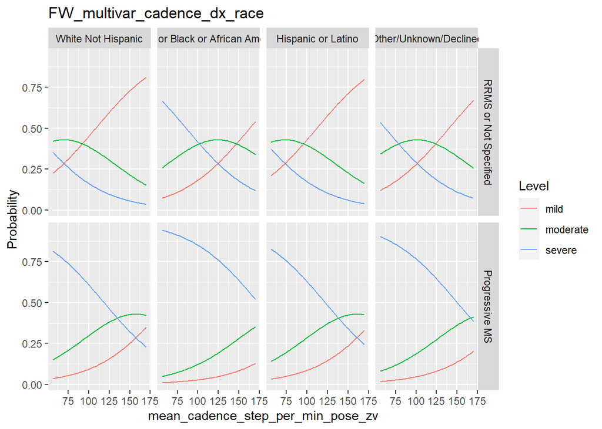

```r
# plot all of the predicted probabilities for the different conditions.
# example
#ggplot(lnewdat, aes(x = gpa, y = Probability, colour = Level)) +
  #geom_line() + facet_grid(pared ~ public, labeller="label_both")

p <- ggplot(lnewdat, aes(x = mean_cadence_step_per_min_pose_zv, y = Probability, colour = Level)) +
  geom_line() +
  facet_grid(ms_dx_condensed_2 ~ race_ethnicity_clean_2) +
  labs(title = filename)
p
```

```r
ggsave(file.path(output_dir, paste(filename, "probabilities.png", sep = "_")))
```

Race, MS DX, and StrideWidth

```r
filename = "FW_multivar_strideWidth_dx_race"

# model
FW_multivar_strideWidth_dx_race <- polr(edss_severity_cat ~ stride_width_median_cm_pose_zv +
                              ms_dx_condensed_2 +
                              race_ethnicity_clean_2,
                            data = zeno_fw_edss_df, Hess=TRUE)


summary_calc_p_and_odds(polr_object = FW_multivar_strideWidth_dx_race,
                        file_name = filename)
```

```
## Call:
## polr(formula = edss_severity_cat ~ stride_width_median_cm_pose_zv +
##     ms_dx_condensed_2 + race_ethnicity_clean_2, data = zeno_fw_edss_df,
##     Hess = TRUE)
##
## Coefficients:
##                                                            Value Std. Error
## stride_width_median_cm_pose_zv                           0.14992    0.07698
## ms_dx_condensed_2Progressive MS                          2.50132    0.58430
## race_ethnicity_clean_2Asian or Black or African American 1.04619    0.61374
## race_ethnicity_clean_2Hispanic or Latino                 0.08066    0.67269
## race_ethnicity_clean_2Other/Unknown/Declined             1.00165    0.89403
##                                                          t value
## stride_width_median_cm_pose_zv                            1.9475
## ms_dx_condensed_2Progressive MS                           4.2809
## race_ethnicity_clean_2Asian or Black or African American  1.7046
## race_ethnicity_clean_2Hispanic or Latino                  0.1199
## race_ethnicity_clean_2Other/Unknown/Declined              1.1204
##
## Intercepts:
##                 Value  Std. Error t value
## mild|moderate   2.1553 0.9765     2.2070
## moderate|severe 3.9992 1.0399     3.8458
##
## Residual Deviance: 181.3763
## AIC: 195.3763
## [1] "Add p-value"
##                                                               Value Std. Error
## stride_width_median_cm_pose_zv                           0.14992315 0.07698133
## ms_dx_condensed_2Progressive MS                          2.50131786 0.58430253
## race_ethnicity_clean_2Asian or Black or African American 1.04619421 0.61373836
## race_ethnicity_clean_2Hispanic or Latino                 0.08065959 0.67269113
## race_ethnicity_clean_2Other/Unknown/Declined             1.00164955 0.89402949
## mild|moderate                                            2.15526777 0.97654579
## moderate|severe                                          3.99916504 1.03986681
##                                                            t value      p.value
## stride_width_median_cm_pose_zv                           1.9475261 5.147169e-02
## ms_dx_condensed_2Progressive MS                          4.2808609 1.861717e-05
## race_ethnicity_clean_2Asian or Black or African American 1.7046257 8.826425e-02
## race_ethnicity_clean_2Hispanic or Latino                 0.1199058 9.045577e-01
## race_ethnicity_clean_2Other/Unknown/Declined             1.1203764 2.625534e-01
## mild|moderate                                            2.2070320 2.731183e-02
## moderate|severe                                          3.8458435 1.201384e-04
```

```
## [1] 0.002009942
## [1] "Odds Ratio and CI"
##                                                                 OR  ci_2.5%
## stride_width_median_cm_pose_zv                            1.161745 1.002012
## ms_dx_condensed_2Progressive MS                          12.198559 1.002012
## race_ethnicity_clean_2Asian or Black or African American  2.846796 1.002012
## race_ethnicity_clean_2Hispanic or Latino                  1.084002 1.002012
## race_ethnicity_clean_2Other/Unknown/Declined              2.722769 1.002012
##                                                          ci_97.5%
## stride_width_median_cm_pose_zv                           4.044248
## ms_dx_condensed_2Progressive MS                          4.044248
## race_ethnicity_clean_2Asian or Black or African American 4.044248
## race_ethnicity_clean_2Hispanic or Latino                 4.044248
## race_ethnicity_clean_2Other/Unknown/Declined             4.044248
```

```
## as.numeric(edss_severity_cat)      N= 100
##
## +------------------------------+----------------------------------+---+----+----+----------+
## |                              |                                  |  N|Y>=1|Y>=2|      Y>=3|
## +------------------------------+----------------------------------+---+----+----+----------+
## |stride_width_median_cm_pose_zv|                      [ 5.72,10.5)| 25| Inf|   0|-0.7032996|
## |                              |                      [10.49,12.4)| 25| Inf|   0|-2.0724729|
## |                              |                      [12.35,13.8)| 25| Inf|   0|-1.7382708|
## |                              |                      [13.81,23.7]| 25| Inf|   0|-1.5198258|
## +------------------------------+----------------------------------+---+----+----+----------+
## |             ms_dx_condensed_2|             RRMS or Not Specified| 82| Inf|   0|-1.6169851|
## |                              |                    Progressive MS| 18| Inf|   0|-2.3812282|
## +------------------------------+----------------------------------+---+----+----+----------+
## |        race_ethnicity_clean_2|                White Not Hispanic| 69| Inf|   0|-1.7033266|
## |                              |Asian or Black or African American| 14| Inf|   0|-1.2039728|
## |                              |                Hispanic or Latino| 11| Inf|   0|-0.7985077|
## |                              |            Other/Unknown/Declined|  6| Inf|   0|-0.6931472|
## +------------------------------+----------------------------------+---+----+----+----------+
## |                       Overall|                                  |100| Inf|   0|-1.4089819|
## +------------------------------+----------------------------------+---+----+----+----------+
```

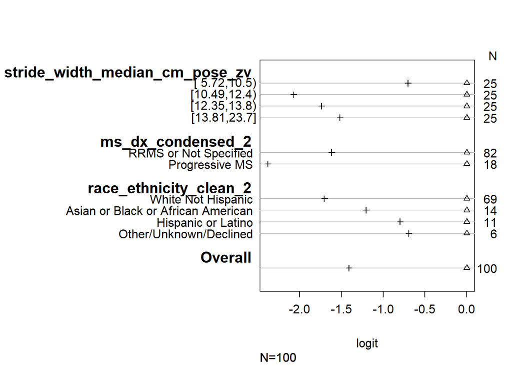

```r
# calculate the log odds of being greater than or equal to each value of the target variable
s <- with(zeno_fw_edss_df, summary(as.numeric(edss_severity_cat) ~ stride_width_median_cm_pose_zv +
                                      ms_dx_condensed_2 +
                                      race_ethnicity_clean_2,
                                    fun=sf))
plot_check_assumption(s)
```

```r
# save original levels to create df
ms_dx_levels <- levels(FW_multivar_strideWidth_dx_race$model$ms_dx_condensed_2)
ms_dx_levels
```

```
## [1] "RRMS or Not Specified" "Progressive MS"
```

```r
race_levels <- levels(FW_multivar_logPixdx_race$model$race_ethnicity_clean_2)
race_levels
```

```
## [1] "White Not Hispanic"                 "Asian or Black or African American"
## [3] "Hispanic or Latino"                 "Other/Unknown/Declined"
```

```r
# Define continuous variable ranges
stride_width_values <- seq(from = 5.72, to = 23.7, length.out = 100)

# Generate all combinations of categorical variables
cat_combinations <- expand.grid(
  ms_dx_condensed_2 = ms_dx_levels,
  race_ethnicity_clean_2 = race_levels,
  stringsAsFactors = TRUE  # Ensures they are factors
)

head(cat_combinations)
```

```
##       ms_dx_condensed_2             race_ethnicity_clean_2
## 1 RRMS or Not Specified                 White Not Hispanic
## 2        Progressive MS                 White Not Hispanic
## 3 RRMS or Not Specified Asian or Black or African American
## 4        Progressive MS Asian or Black or African American
## 5 RRMS or Not Specified                 Hispanic or Latino
## 6        Progressive MS                 Hispanic or Latino
```

```r
# Expand dataset to include all continuous variable values for each categorical combination
newdat <- expand.grid(
  stride_width_median_cm_pose_zv = stride_width_values,
  stringsAsFactors = FALSE  # Keep continuous variables numeric
)

# Use `merge()` to properly combine categorical and continuous variables
newdat <- merge(cat_combinations, newdat, by = NULL)

# predict for each row of new dat using model
newdat <- cbind(newdat, predict(FW_multivar_strideWidth_dx_race, newdat, type = "probs"))
head(newdat)
```

```
##       ms_dx_condensed_2             race_ethnicity_clean_2
## 1 RRMS or Not Specified                 White Not Hispanic
## 2        Progressive MS                 White Not Hispanic
## 3 RRMS or Not Specified Asian or Black or African American
## 4        Progressive MS Asian or Black or African American
## 5 RRMS or Not Specified                 Hispanic or Latino
## 6        Progressive MS                 Hispanic or Latino
##   stride_width_median_cm_pose_zv       mild  moderate     severe
## 1                           5.72 0.78544888 0.1731278 0.04142336
## 2                           5.72 0.23083355 0.4239847 0.34518172
## 3                           5.72 0.56254890 0.3279074 0.10954371
## 4                           5.72 0.09536631 0.3045275 0.60010616
## 5                           5.72 0.77154359 0.1837091 0.04474729
## 6                           5.72 0.21682423 0.4195420 0.36363373
```

```r
# reshape for plotting
lnewdat <- melt(newdat, id.vars = c("stride_width_median_cm_pose_zv",
                                    "ms_dx_condensed_2",
                                    "race_ethnicity_clean_2"),
                variable.name = "Level", value.name="Probability")
head(lnewdat)
```

```
##   stride_width_median_cm_pose_zv     ms_dx_condensed_2
## 1                           5.72 RRMS or Not Specified
## 2                           5.72        Progressive MS
## 3                           5.72 RRMS or Not Specified
## 4                           5.72        Progressive MS
## 5                           5.72 RRMS or Not Specified
## 6                           5.72        Progressive MS
##               race_ethnicity_clean_2 Level Probability
## 1                 White Not Hispanic  mild  0.78544888
## 2                 White Not Hispanic  mild  0.23083355
## 3 Asian or Black or African American  mild  0.56254890
## 4 Asian or Black or African American  mild  0.09536631
## 5                 Hispanic or Latino  mild  0.77154359
## 6                 Hispanic or Latino  mild  0.21682423
```

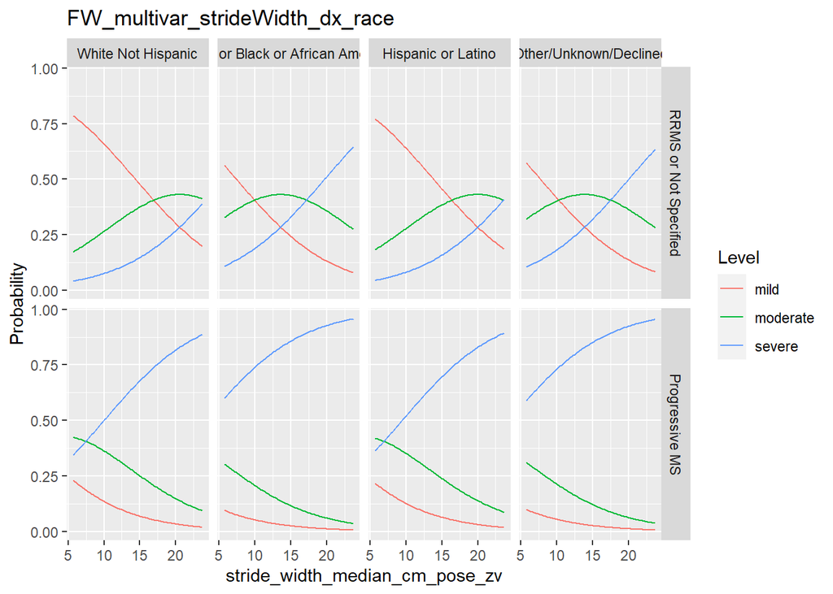

```r
# plot all of the predicted probabilities for the different conditions.
# example
#ggplot(lnewdat, aes(x = gpa, y = Probability, colour = Level)) +
  #geom_line() + facet_grid(pared ~ public, labeller="label_both")

p <- ggplot(lnewdat, aes(x = stride_width_median_cm_pose_zv, y = Probability, colour = Level)) +
  geom_line() +
  facet_grid(ms_dx_condensed_2 ~ race_ethnicity_clean_2) +
  labs(title = filename)
p
```

```r
ggsave(file.path(output_dir, paste(filename, "probabilities.png", sep = "_")))
```